# Sparkify Project Workspace

This workspace contains a tiny subset (128MB) of the full dataset available (12GB). Feel free to use this workspace to build your project, or to explore a smaller subset with Spark before deploying your cluster on the cloud. Instructions for setting up your Spark cluster is included in the last lesson of the Extracurricular Spark Course content.

You can follow the steps below to guide your data analysis and model building portion of this project.

**Business Objective** To find users that are about to either down grade or cancel the service. so that business can give them specail offers before they churn.

**Study Objective**

1. Explore similarity betwenn pandas & spark dataframes
2. Explore spark sql apis & description apis
3. conclude which is good for data analysis

Medium blog explins the project detedails and my experience in workign with spark. I had 2 objective, first a classification problem and second exploration of spark ecosystem. in future if i had to make choice between Spark vs Pandas which one to use ? if its spark will it be spark sql or spark declaritive ?

So in below project , I did repetiative steps , in data exploration I did comparision between Pandas vs Spark. later in feature engeering section I compare spark sql & spark declaritive

blog link : https://medium.com/@odmirajkar/spark-vs-pandas-f149caa2d643

```python
# import libraries
from pyspark.sql import SparkSession,Window
import pandas as pd
from pyspark.sql.functions import isnan, when, count, col,udf,max
from matplotlib import pyplot as plt
import datetime
import re
from pyspark.sql.types import IntegerType
from pyspark.ml.feature import VectorAssembler
from pyspark.ml.classification import RandomForestClassifier,GBTClassifier
from pyspark.ml.feature import StandardScaler
from pyspark.ml.tuning import CrossValidator, ParamGridBuilder
from pyspark.ml.evaluation import MulticlassClassificationEvaluator
import time
from pyspark.ml.evaluation import BinaryClassificationEvaluator
```

```python
# create a Spark session
spark = SparkSession.builder \
    .master("local") \
    .appName("my_sparkify") \
    .getOrCreate()

df = spark.read.json('mini_sparkify_event_data.json')
```

```python
df.createOrReplaceTempView("sparkify")
```

**Study Objective Reading Data and creating dataframe**

- Both spark and pandas can read data from various sources csv, json,dabase tables
- For Spark we can use spark.read. methodes
- For Pandas we have pd.read_ methods
- Spark dataframe can be converted into Pandas dataframe using toPandas method of dataframe

```python
pd_df=df.toPandas()
```

# Load and Clean Dataset

In this workspace, the mini-dataset file is `mini_sparkify_event_data.json`. Load and clean the dataset, checking for invalid or missing data - for example, records without userids or sessionids.

**Study Objective Dimention properties of dataframe**

1. shape of dataframe
2. No of rows in dataframe
3. No of colunms in dataframe

```python
print("No of rows in dataframe : ",df.count())
print("No of rows in dataframe : ",pd_df.shape[0])
```

```
No of rows in dataframe :  286500
No of rows in dataframe :  286500
```

```python
print("No of colunms in dataframe : ",len(df.columns))
print("No of colunms in dataframe : ",pd_df.shape[1])
```

```
No of colunms in dataframe :  18
No of colunms in dataframe :  18
```

```python
print("Colunms name in dataframe ",df.columns)
print("Colunms name in dataframe ",pd_df.columns)
```

```
Colunms name in dataframe  ['artist', 'auth', 'firstName', 'gender', 'itemInSession', 'lastName', 'length', 'level', 'location', 'method', 'page', 'registration', 'sessionId', 'song', 'status', 'ts', 'userAgent', 'userId']
Colunms name in dataframe  Index(['artist', 'auth', 'firstName', 'gender', 'itemInSession', 'lastName',
       'length', 'level', 'location', 'method', 'page', 'registration',
       'sessionId', 'song', 'status', 'ts', 'userAgent', 'userId'],
      dtype='object')
```

**Study Objective Summary of dataframe**

1. Describe each colunms along with its data type
2. Describe numeric stats of numeric data type

```python
df.summary()
```

```
DataFrame[summary: string, artist: string, auth: string, firstName: string, gender: string, itemInSession: string, lastName: string, length: string, level: string, location: string, method: string, page: string, registration: string, sessionId: string, song: string, status: string, ts: string, userA…
```

```python
pd_df.describe()
```

|  | itemInSession | length | registration | sessionId | status | ts |
| --- | --- | --- | --- | --- | --- | --- |
| count | 286500.000000 | 228108.000000 | 2.781540e+05 | 286500.000000 | 286500.000000 | 2.865000e+05 |
| mean | 114.414213 | 249.117182 | 1.535359e+12 | 1041.526555 | 210.054597 | 1.540957e+12 |
| std | 129.767262 | 99.235179 | 3.291322e+09 | 726.776263 | 31.505078 | 1.507544e+09 |
| min | 0.000000 | 0.783220 | 1.521381e+12 | 1.000000 | 200.000000 | 1.538352e+12 |
| 25% | 27.000000 | 199.888530 | 1.533522e+12 | 336.000000 | 200.000000 | 1.539697e+12 |
| 50% | 70.000000 | 234.500770 | 1.536664e+12 | 1013.000000 | 200.000000 | 1.540932e+12 |
| 75% | 156.250000 | 277.158730 | 1.537672e+12 | 1675.000000 | 200.000000 | 1.542266e+12 |
| max | 1321.000000 | 3024.665670 | 1.543247e+12 | 2474.000000 | 404.000000 | 1.543799e+12 |

```python
df.describe('itemInSession')
```

```
DataFrame[summary: string, itemInSession: string]
```

```python
df.printSchema()
```

```
root
 |-- artist: string (nullable = true)
 |-- auth: string (nullable = true)
 |-- firstName: string (nullable = true)
 |-- gender: string (nullable = true)
 |-- itemInSession: long (nullable = true)
 |-- lastName: string (nullable = true)
 |-- length: double (nullable = true)
 |-- level: string (nullable = true)
 |-- location: string (nullable = true)
 |-- method: string (nullable = true)
 |-- page: string (nullable = true)
 |-- registration: long (nullable = true)
 |-- sessionId: long (nullable = true)
 |-- song: string (nullable = true)
 |-- status: long (nullable = true)
 |-- ts: long (nullable = true)
 |-- userAgent: string (nullable = true)
 |-- userId: string (nullable = true)
```

**Study Objective Display dataframe**

1. First n rowns of dataframe
2. Display First n rows of a colunms
3. display multiple colunms

```python
df.show(5)
```

```
+----------------+---------+---------+------+-------------+--------+---------+-----+--------------------+------+--------+-------------+---------+--------------------+------+-------------+--------------------+------+
|          artist|     auth|firstName|gender|itemInSession|lastName|   length|level|            location|method|    page| registration|sessionId|                song|status|           ts|           userAgent|userId|
+----------------+---------+---------+------+-------------+--------+---------+-----+--------------------+------+--------+-------------+---------+--------------------+------+-------------+--------------------+------+
|  Martha Tilston|Logged In|    Colin|     M|           50| Freeman|277.89016| paid|     Bakersfield, CA|   PUT|NextSong|1538173362000|       29|           Rockpools|   200|1538352117000|Mozilla/5.0 (Wind...|    30|
|Five Iron Frenzy|Logged In|    Micah|     M|           79|    Long|236.09424| free|Boston-Cambridge-...|   PUT|NextSong|1538331630000|        8|              Canada|   200|1538352180000|"Mozilla/5.0 (Win...|     9|
|    Adam Lambert|Logged In|    Colin|     M|           51| Freeman| 282.8273| paid|     Bakersfield, CA|   PUT|NextSong|1538173362000|       29|   Time For Miracles|   200|1538352394000|Mozilla/5.0 (Wind...|    30|
|          Enigma|Logged In|    Micah|     M|           80|    Long|262.71302| free|Boston-Cambridge-...|   PUT|NextSong|1538331630000|        8|Knocking On Forbi...|   200|1538352416000|"Mozilla/5.0 (Win...|     9|
|       Daft Punk|Logged In|    Colin|     M|           52| Freeman|223.60771| paid|     Bakersfield, CA|   PUT|NextSong|1538173362000|       29|Harder Better Fas...|   200|1538352676000|Mozilla/5.0 (Wind...|    30|
+----------------+---------+---------+------+-------------+--------+---------+-----+--------------------+------+--------+-------------+---------+--------------------+------+-------------+--------------------+------+
only showing top 5 rows
```

```python
query=spark.sql("select * from sparkify Limit 5")
query.show()
```

```
+----------------+---------+---------+------+-------------+--------+---------+-----+--------------------+------+--------+-------------+---------+--------------------+------+-------------+--------------------+------+
|          artist|     auth|firstName|gender|itemInSession|lastName|   length|level|            location|method|    page| registration|sessionId|                song|status|           ts|           userAgent|userId|
+----------------+---------+---------+------+-------------+--------+---------+-----+--------------------+------+--------+-------------+---------+--------------------+------+-------------+--------------------+------+
|  Martha Tilston|Logged In|    Colin|     M|           50| Freeman|277.89016| paid|     Bakersfield, CA|   PUT|NextSong|1538173362000|       29|           Rockpools|   200|1538352117000|Mozilla/5.0 (Wind...|    30|
|Five Iron Frenzy|Logged In|    Micah|     M|           79|    Long|236.09424| free|Boston-Cambridge-...|   PUT|NextSong|1538331630000|        8|              Canada|   200|1538352180000|"Mozilla/5.0 (Win...|     9|
|    Adam Lambert|Logged In|    Colin|     M|           51| Freeman| 282.8273| paid|     Bakersfield, CA|   PUT|NextSong|1538173362000|       29|   Time For Miracles|   200|1538352394000|Mozilla/5.0 (Wind...|    30|
|          Enigma|Logged In|    Micah|     M|           80|    Long|262.71302| free|Boston-Cambridge-...|   PUT|NextSong|1538331630000|        8|Knocking On Forbi...|   200|1538352416000|"Mozilla/5.0 (Win...|     9|
|       Daft Punk|Logged In|    Colin|     M|           52| Freeman|223.60771| paid|     Bakersfield, CA|   PUT|NextSong|1538173362000|       29|Harder Better Fas...|   200|1538352676000|Mozilla/5.0 (Wind...|    30|
+----------------+---------+---------+------+-------------+--------+---------+-----+--------------------+------+--------+-------------+---------+--------------------+------+-------------+--------------------+------+
```

```python
pd_df.head(5)
```

|  | artist | auth | firstName | gender | itemInSession | lastName | length | level | location | method | page | registration | sessionId | song | status | ts | userAgent | userId |
| --- | --- | --- | --- | --- | --- | --- | --- | --- | --- | --- | --- | --- | --- | --- | --- | --- | --- | --- |
| 0 | Martha Tilston | Logged In | Colin | M | 50 | Freeman | 277.89016 | paid | Bakersfield, CA | PUT | NextSong | 1.538173e+12 | 29 | Rockpools | 200 | 1538352117000 | Mozilla/5.0 (Windows NT 6.1; WOW64; rv:31.0) G... | 30 |
| 1 | Five Iron Frenzy | Logged In | Micah | M | 79 | Long | 236.09424 | free | Boston-Cambridge-Newton, MA-NH | PUT | NextSong | 1.538332e+12 | 8 | Canada | 200 | 1538352180000 | "Mozilla/5.0 (Windows NT 6.1; WOW64) AppleWebK... | 9 |
| 2 | Adam Lambert | Logged In | Colin | M | 51 | Freeman | 282.82730 | paid | Bakersfield, CA | PUT | NextSong | 1.538173e+12 | 29 | Time For Miracles | 200 | 1538352394000 | Mozilla/5.0 (Windows NT 6.1; WOW64; rv:31.0) G... | 30 |
| 3 | Enigma | Logged In | Micah | M | 80 | Long | 262.71302 | free | Boston-Cambridge-Newton, MA-NH | PUT | NextSong | 1.538332e+12 | 8 | Knocking On Forbidden Doors | 200 | 1538352416000 | "Mozilla/5.0 (Windows NT 6.1; WOW64) AppleWebK... | 9 |
| 4 | Daft Punk | Logged In | Colin | M | 52 | Freeman | 223.60771 | paid | Bakersfield, CA | PUT | NextSong | 1.538173e+12 | 29 | Harder Better Faster Stronger | 200 | 1538352676000 | Mozilla/5.0 (Windows NT 6.1; WOW64; rv:31.0) G... | 30 |

```python
df.take(3)
```

```
[Row(artist='Martha Tilston', auth='Logged In', firstName='Colin', gender='M', itemInSession=50, lastName='Freeman', length=277.89016, level='paid', location='Bakersfield, CA', method='PUT', page='NextSong', registration=1538173362000, sessionId=29, song='Rockpools', status=200, ts=1538352117000, us…
 Row(artist='Five Iron Frenzy', auth='Logged In', firstName='Micah', gender='M', itemInSession=79, lastName='Long', length=236.09424, level='free', location='Boston-Cambridge-Newton, MA-NH', method='PUT', page='NextSong', registration=1538331630000, sessionId=8, song='Canada', status=200, ts=1538352…
 Row(artist='Adam Lambert', auth='Logged In', firstName='Colin', gender='M', itemInSession=51, lastName='Freeman', length=282.8273, level='paid', location='Bakersfield, CA', method='PUT', page='NextSong', registration=1538173362000, sessionId=29, song='Time For Miracles', status=200, ts=153835239400…
```

```python
pd_df.tail(2)
```

|  | artist | auth | firstName | gender | itemInSession | lastName | length | level | location | method | page | registration | sessionId | song | status | ts | userAgent | userId |
| --- | --- | --- | --- | --- | --- | --- | --- | --- | --- | --- | --- | --- | --- | --- | --- | --- | --- | --- |
| 286498 | None | Logged In | Emilia | F | 44 | House | NaN | paid | New York-Newark-Jersey City, NY-NJ-PA | GET | About | 1.538337e+12 | 500 | None | 200 | 1543622398000 | Mozilla/5.0 (compatible; MSIE 9.0; Windows NT ... | 300011 |
| 286499 | Camera Obscura | Logged In | Emilia | F | 45 | House | 170.89261 | paid | New York-Newark-Jersey City, NY-NJ-PA | PUT | NextSong | 1.538337e+12 | 500 | The Sun On His Back | 200 | 1543622411000 | Mozilla/5.0 (compatible; MSIE 9.0; Windows NT ... | 300011 |

```python
df.select('artist').show(10)
```

```
+--------------------+
|              artist|
+--------------------+
|      Martha Tilston|
|    Five Iron Frenzy|
|        Adam Lambert|
|              Enigma|
|           Daft Punk|
|The All-American ...|
|The Velvet Underg...|
|        Starflyer 59|
|                null|
|            Frumpies|
+--------------------+
only showing top 10 rows
```

```python
query=spark.sql("select artist from sparkify LIMIT 10")
query.show()
```

```
+--------------------+
|              artist|
+--------------------+
|      Martha Tilston|
|    Five Iron Frenzy|
|        Adam Lambert|
|              Enigma|
|           Daft Punk|
|The All-American ...|
|The Velvet Underg...|
|        Starflyer 59|
|                null|
|            Frumpies|
+--------------------+
```

```python
pd_df['artist'].head(10)
```

```
0                   Martha Tilston
1                 Five Iron Frenzy
2                     Adam Lambert
3                           Enigma
4                        Daft Punk
5         The All-American Rejects
6    The Velvet Underground / Nico
7                     Starflyer 59
8                             None
9                         Frumpies
Name: artist, dtype: object
```

```python
df.select(['artist','auth','firstName']).show(5)
```

```
+----------------+---------+---------+
|          artist|     auth|firstName|
+----------------+---------+---------+
|  Martha Tilston|Logged In|    Colin|
|Five Iron Frenzy|Logged In|    Micah|
|    Adam Lambert|Logged In|    Colin|
|          Enigma|Logged In|    Micah|
|       Daft Punk|Logged In|    Colin|
+----------------+---------+---------+
only showing top 5 rows
```

```python
query=spark.sql("select artist,auth,firstName from sparkify LIMIT 10")
query.show()
```

```
+--------------------+---------+---------+
|              artist|     auth|firstName|
+--------------------+---------+---------+
|      Martha Tilston|Logged In|    Colin|
|    Five Iron Frenzy|Logged In|    Micah|
|        Adam Lambert|Logged In|    Colin|
|              Enigma|Logged In|    Micah|
|           Daft Punk|Logged In|    Colin|
|The All-American ...|Logged In|    Micah|
|The Velvet Underg...|Logged In|    Micah|
|        Starflyer 59|Logged In|    Colin|
|                null|Logged In|    Colin|
|            Frumpies|Logged In|    Colin|
+--------------------+---------+---------+
```

```python
pd_df[['artist','auth','firstName']].head(5)
```

|  | artist | auth | firstName |
| --- | --- | --- | --- |
| 0 | Martha Tilston | Logged In | Colin |
| 1 | Five Iron Frenzy | Logged In | Micah |
| 2 | Adam Lambert | Logged In | Colin |
| 3 | Enigma | Logged In | Micah |
| 4 | Daft Punk | Logged In | Colin |

**Study Objective Filtering Rows**

1. Fiter based on single colunms

```python
df[df.userId == "300011"].show()
```

```
+--------------------+---------+---------+------+-------------+--------+---------+-----+--------------------+------+-----------+-------------+---------+--------------------+------+-------------+--------------------+------+
|              artist|     auth|firstName|gender|itemInSession|lastName|   length|level|            location|method|       page| registration|sessionId|                song|status|           ts|           userAgent|userId|
+--------------------+---------+---------+------+-------------+--------+---------+-----+--------------------+------+-----------+-------------+---------+--------------------+------+-------------+--------------------+------+
|             La Roux|Logged In|   Emilia|     F|            0|   House|233.11628| free|New York-Newark-J...|   PUT|   NextSong|1538336771000|       11|         Armour Love|   200|1538430493000|Mozilla/5.0 (comp...|300011|
|    Dropkick Murphys|Logged In|   Emilia|     F|            1|   House|233.53424| free|New York-Newark-J...|   PUT|   NextSong|1538336771000|       11|     The Dirty Glass|   200|1538430726000|Mozilla/5.0 (comp...|300011|
|        Jack Johnson|Logged In|   Emilia|     F|            2|   House|196.20526| free|New York-Newark-J...|   PUT|   NextSong|1538336771000|       11|  You And Your Heart|   200|1538430959000|Mozilla/5.0 (comp...|300011|
|        Deana Carter|Logged In|   Emilia|     F|            3|   House| 214.5171| free|New York-Newark-J...|   PUT|   NextSong|1538336771000|       11|  She's Good For You|   200|1538431155000|Mozilla/5.0 (comp...|300011|
|Circle Of Dead Ch...|Logged In|   Emilia|     F|            4|   House|101.14567| free|New York-Newark-J...|   PUT|   NextSong|1538336771000|       11|Born On A Bomb Shell|   200|1538431369000|Mozilla/5.0 (comp...|300011|
|                null|Logged In|   Emilia|     F|            5|   House|     null| free|New York-Newark-J...|   GET|       Home|1538336771000|       11|                null|   200|1538431467000|Mozilla/5.0 (comp...|300011|
|      Iron Butterfly|Logged In|   Emilia|     F|            6|   House|182.12526| free|New York-Newark-J...|   PUT|   NextSong|1538336771000|       11|  In-A-Gadda-Da-Vida|   200|1538431470000|Mozilla/5.0 (comp...|300011|
|         OneRepublic|Logged In|   Emilia|     F|            7|   House|242.93832| free|New York-Newark-J...|   PUT|   NextSong|1538336771000|       11|       All This Time|   200|1538431652000|Mozilla/5.0 (comp...|300011|
|          Miike Snow|Logged In|   Emilia|     F|            8|   House|263.88853| free|New York-Newark-J...|   PUT|   NextSong|1538336771000|       11|              Animal|   200|1538431894000|Mozilla/5.0 (comp...|300011|
|          Irene Cara|Logged In|   Emilia|     F|            9|   House|244.53179| free|New York-Newark-J...|   PUT|   NextSong|1538336771000|       11|      What A Feeling|   200|1538432157000|Mozilla/5.0 (comp...|300011|
|                null|Logged In|   Emilia|     F|           10|   House|     null| free|New York-Newark-J...|   GET|Roll Advert|1538336771000|       11|                null|   200|1538432189000|Mozilla/5.0 (comp...|300011|
|      Charlie Louvin|Logged In|   Emilia|     F|           11|   House|170.86649| free|New York-Newark-J...|   PUT|   NextSong|1538336771000|       11|   I Think I'll Live|   200|1538432401000|Mozilla/5.0 (comp...|300011|
|    Jimmy McCracklin|Logged In|   Emilia|     F|           12|   House|166.97424| free|New York-Newark-J...|   PUT|   NextSong|1538336771000|       11| I'll Take The Blame|   200|1538432571000|Mozilla/5.0 (comp...|300011|
|           The Dodos|Logged In|   Emilia|     F|           13|   House|441.88689| free|New York-Newark-J...|   PUT|   NextSong|1538336771000|       11|         Joe's Waltz|   200|1538432737000|Mozilla/5.0 (comp...|300011|
|  DHT Feat. EdmÃÂ©e|Logged In|   Emilia|     F|           14|   House|229.98159| free|New York-Newark-J...|   PUT|   NextSong|1538336771000|       11|Listen To Your Heart|   200|1538433178000|Mozilla/5.0 (comp...|300011|
|        Fall Out Boy|Logged In|   Emilia|     F|           15|   House|211.46077| free|New York-Newark-J...|   PUT|   NextSong|1538336771000|       11|I Slept With Some...|   200|1538433407000|Mozilla/5.0 (comp...|300011|
|       Kings Of Leon|Logged In|   Emilia|     F|           16|   House|231.81016| free|New York-Newark-J...|   PUT|   NextSong|1538336771000|       11|        Use Somebody|   200|1538433618000|Mozilla/5.0 (comp...|300011|
|                null|Logged In|   Emilia|     F|           17|   House|     null| free|New York-Newark-J...|   PUT|  Thumbs Up|1538336771000|       11|                null|   307|1538433619000|Mozilla/5.0 (comp...|300011|
|           Ry Cooder|Logged In|   Emilia|     F|           18|   House|201.56036| free|New York-Newark-J...|   PUT|   NextSong|1538336771000|       11|    Corrido de Boxeo|   200|1538433849000|Mozilla/5.0 (comp...|300011|
|      The Mars Volta|Logged In|   Emilia|     F|           19|   House|380.42077| free|New York-Newark-J...|   PUT|   NextSong|1538336771000|       11|           Eriatarka|   200|1538434050000|Mozilla/5.0 (comp...|300011|
+--------------------+---------+---------+------+-------------+--------+---------+-----+--------------------+------+-----------+-------------+---------+--------------------+------+-------------+--------------------+------+
only showing top 20 rows
```

```python
## using sql apis of spark
query=spark.sql("select * from sparkify where userId = '300011' LIMIT 10")
query.show()
```

```
+--------------------+---------+---------+------+-------------+--------+---------+-----+--------------------+------+--------+-------------+---------+--------------------+------+-------------+--------------------+------+
|              artist|     auth|firstName|gender|itemInSession|lastName|   length|level|            location|method|    page| registration|sessionId|                song|status|           ts|           userAgent|userId|
+--------------------+---------+---------+------+-------------+--------+---------+-----+--------------------+------+--------+-------------+---------+--------------------+------+-------------+--------------------+------+
|             La Roux|Logged In|   Emilia|     F|            0|   House|233.11628| free|New York-Newark-J...|   PUT|NextSong|1538336771000|       11|         Armour Love|   200|1538430493000|Mozilla/5.0 (comp...|300011|
|    Dropkick Murphys|Logged In|   Emilia|     F|            1|   House|233.53424| free|New York-Newark-J...|   PUT|NextSong|1538336771000|       11|     The Dirty Glass|   200|1538430726000|Mozilla/5.0 (comp...|300011|
|        Jack Johnson|Logged In|   Emilia|     F|            2|   House|196.20526| free|New York-Newark-J...|   PUT|NextSong|1538336771000|       11|  You And Your Heart|   200|1538430959000|Mozilla/5.0 (comp...|300011|
|        Deana Carter|Logged In|   Emilia|     F|            3|   House| 214.5171| free|New York-Newark-J...|   PUT|NextSong|1538336771000|       11|  She's Good For You|   200|1538431155000|Mozilla/5.0 (comp...|300011|
|Circle Of Dead Ch...|Logged In|   Emilia|     F|            4|   House|101.14567| free|New York-Newark-J...|   PUT|NextSong|1538336771000|       11|Born On A Bomb Shell|   200|1538431369000|Mozilla/5.0 (comp...|300011|
|                null|Logged In|   Emilia|     F|            5|   House|     null| free|New York-Newark-J...|   GET|    Home|1538336771000|       11|                null|   200|1538431467000|Mozilla/5.0 (comp...|300011|
|      Iron Butterfly|Logged In|   Emilia|     F|            6|   House|182.12526| free|New York-Newark-J...|   PUT|NextSong|1538336771000|       11|  In-A-Gadda-Da-Vida|   200|1538431470000|Mozilla/5.0 (comp...|300011|
|         OneRepublic|Logged In|   Emilia|     F|            7|   House|242.93832| free|New York-Newark-J...|   PUT|NextSong|1538336771000|       11|       All This Time|   200|1538431652000|Mozilla/5.0 (comp...|300011|
|          Miike Snow|Logged In|   Emilia|     F|            8|   House|263.88853| free|New York-Newark-J...|   PUT|NextSong|1538336771000|       11|              Animal|   200|1538431894000|Mozilla/5.0 (comp...|300011|
|          Irene Cara|Logged In|   Emilia|     F|            9|   House|244.53179| free|New York-Newark-J...|   PUT|NextSong|1538336771000|       11|      What A Feeling|   200|1538432157000|Mozilla/5.0 (comp...|300011|
+--------------------+---------+---------+------+-------------+--------+---------+-----+--------------------+------+--------+-------------+---------+--------------------+------+-------------+--------------------+------+
```

```python
pd_df[pd_df['userId']=="300011"].head(5)
```

|  | artist | auth | firstName | gender | itemInSession | lastName | length | level | location | method | page | registration | sessionId | song | status | ts | userAgent | userId |
| --- | --- | --- | --- | --- | --- | --- | --- | --- | --- | --- | --- | --- | --- | --- | --- | --- | --- | --- |
| 249009 | La Roux | Logged In | Emilia | F | 0 | House | 233.11628 | free | New York-Newark-Jersey City, NY-NJ-PA | PUT | NextSong | 1.538337e+12 | 11 | Armour Love | 200 | 1538430493000 | Mozilla/5.0 (compatible; MSIE 9.0; Windows NT ... | 300011 |
| 249011 | Dropkick Murphys | Logged In | Emilia | F | 1 | House | 233.53424 | free | New York-Newark-Jersey City, NY-NJ-PA | PUT | NextSong | 1.538337e+12 | 11 | The Dirty Glass | 200 | 1538430726000 | Mozilla/5.0 (compatible; MSIE 9.0; Windows NT ... | 300011 |
| 249013 | Jack Johnson | Logged In | Emilia | F | 2 | House | 196.20526 | free | New York-Newark-Jersey City, NY-NJ-PA | PUT | NextSong | 1.538337e+12 | 11 | You And Your Heart | 200 | 1538430959000 | Mozilla/5.0 (compatible; MSIE 9.0; Windows NT ... | 300011 |
| 249015 | Deana Carter | Logged In | Emilia | F | 3 | House | 214.51710 | free | New York-Newark-Jersey City, NY-NJ-PA | PUT | NextSong | 1.538337e+12 | 11 | She's Good For You | 200 | 1538431155000 | Mozilla/5.0 (compatible; MSIE 9.0; Windows NT ... | 300011 |
| 249017 | Circle Of Dead Children | Logged In | Emilia | F | 4 | House | 101.14567 | free | New York-Newark-Jersey City, NY-NJ-PA | PUT | NextSong | 1.538337e+12 | 11 | Born On A Bomb Shell | 200 | 1538431369000 | Mozilla/5.0 (compatible; MSIE 9.0; Windows NT ... | 300011 |

```python
df.filter(df.userId == "300011").show(5)
```

```
+--------------------+---------+---------+------+-------------+--------+---------+-----+--------------------+------+--------+-------------+---------+--------------------+------+-------------+--------------------+------+
|              artist|     auth|firstName|gender|itemInSession|lastName|   length|level|            location|method|    page| registration|sessionId|                song|status|           ts|           userAgent|userId|
+--------------------+---------+---------+------+-------------+--------+---------+-----+--------------------+------+--------+-------------+---------+--------------------+------+-------------+--------------------+------+
|             La Roux|Logged In|   Emilia|     F|            0|   House|233.11628| free|New York-Newark-J...|   PUT|NextSong|1538336771000|       11|         Armour Love|   200|1538430493000|Mozilla/5.0 (comp...|300011|
|    Dropkick Murphys|Logged In|   Emilia|     F|            1|   House|233.53424| free|New York-Newark-J...|   PUT|NextSong|1538336771000|       11|     The Dirty Glass|   200|1538430726000|Mozilla/5.0 (comp...|300011|
|        Jack Johnson|Logged In|   Emilia|     F|            2|   House|196.20526| free|New York-Newark-J...|   PUT|NextSong|1538336771000|       11|  You And Your Heart|   200|1538430959000|Mozilla/5.0 (comp...|300011|
|        Deana Carter|Logged In|   Emilia|     F|            3|   House| 214.5171| free|New York-Newark-J...|   PUT|NextSong|1538336771000|       11|  She's Good For You|   200|1538431155000|Mozilla/5.0 (comp...|300011|
|Circle Of Dead Ch...|Logged In|   Emilia|     F|            4|   House|101.14567| free|New York-Newark-J...|   PUT|NextSong|1538336771000|       11|Born On A Bomb Shell|   200|1538431369000|Mozilla/5.0 (comp...|300011|
+--------------------+---------+---------+------+-------------+--------+---------+-----+--------------------+------+--------+-------------+---------+--------------------+------+-------------+--------------------+------+
only showing top 5 rows
```

```python
df.filter((df.userId == "300011") & (df.artist =='Jack Johnson') ).show(5)
```

```
+------------+---------+---------+------+-------------+--------+---------+-----+--------------------+------+--------+-------------+---------+------------------+------+-------------+--------------------+------+
|      artist|     auth|firstName|gender|itemInSession|lastName|   length|level|            location|method|    page| registration|sessionId|              song|status|           ts|           userAgent|userId|
+------------+---------+---------+------+-------------+--------+---------+-----+--------------------+------+--------+-------------+---------+------------------+------+-------------+--------------------+------+
|Jack Johnson|Logged In|   Emilia|     F|            2|   House|196.20526| free|New York-Newark-J...|   PUT|NextSong|1538336771000|       11|You And Your Heart|   200|1538430959000|Mozilla/5.0 (comp...|300011|
|Jack Johnson|Logged In|   Emilia|     F|          133|   House|236.72118| paid|New York-Newark-J...|   PUT|NextSong|1538336771000|       54|       Bubble Toes|   200|1538538394000|Mozilla/5.0 (comp...|300011|
|Jack Johnson|Logged In|   Emilia|     F|           37|   House|207.64689| paid|New York-Newark-J...|   PUT|NextSong|1538336771000|       80|   Better Together|   200|1538751282000|Mozilla/5.0 (comp...|300011|
|Jack Johnson|Logged In|   Emilia|     F|           71|   House|212.87138| paid|New York-Newark-J...|   PUT|NextSong|1538336771000|      112|        Never Know|   200|1539268213000|Mozilla/5.0 (comp...|300011|
|Jack Johnson|Logged In|   Emilia|     F|            0|   House|185.99138| paid|New York-Newark-J...|   PUT|NextSong|1538336771000|      156|      Crying Shame|   200|1539546866000|Mozilla/5.0 (comp...|300011|
+------------+---------+---------+------+-------------+--------+---------+-----+--------------------+------+--------+-------------+---------+------------------+------+-------------+--------------------+------+
only showing top 5 rows
```

```python
query=spark.sql("select * from sparkify where userId = '300011' and artist = 'Jack Johnson' LIMIT 5")
query.show()
```

```
+------------+---------+---------+------+-------------+--------+---------+-----+--------------------+------+--------+-------------+---------+------------------+------+-------------+--------------------+------+
|      artist|     auth|firstName|gender|itemInSession|lastName|   length|level|            location|method|    page| registration|sessionId|              song|status|           ts|           userAgent|userId|
+------------+---------+---------+------+-------------+--------+---------+-----+--------------------+------+--------+-------------+---------+------------------+------+-------------+--------------------+------+
|Jack Johnson|Logged In|   Emilia|     F|            2|   House|196.20526| free|New York-Newark-J...|   PUT|NextSong|1538336771000|       11|You And Your Heart|   200|1538430959000|Mozilla/5.0 (comp...|300011|
|Jack Johnson|Logged In|   Emilia|     F|          133|   House|236.72118| paid|New York-Newark-J...|   PUT|NextSong|1538336771000|       54|       Bubble Toes|   200|1538538394000|Mozilla/5.0 (comp...|300011|
|Jack Johnson|Logged In|   Emilia|     F|           37|   House|207.64689| paid|New York-Newark-J...|   PUT|NextSong|1538336771000|       80|   Better Together|   200|1538751282000|Mozilla/5.0 (comp...|300011|
|Jack Johnson|Logged In|   Emilia|     F|           71|   House|212.87138| paid|New York-Newark-J...|   PUT|NextSong|1538336771000|      112|        Never Know|   200|1539268213000|Mozilla/5.0 (comp...|300011|
|Jack Johnson|Logged In|   Emilia|     F|            0|   House|185.99138| paid|New York-Newark-J...|   PUT|NextSong|1538336771000|      156|      Crying Shame|   200|1539546866000|Mozilla/5.0 (comp...|300011|
+------------+---------+---------+------+-------------+--------+---------+-----+--------------------+------+--------+-------------+---------+------------------+------+-------------+--------------------+------+
```

```python
pd_df[(pd_df['userId']=="300011") & (pd_df['artist'] =='Jack Johnson')].head(5)
```

|  | artist | auth | firstName | gender | itemInSession | lastName | length | level | location | method | page | registration | sessionId | song | status | ts | userAgent | userId |
| --- | --- | --- | --- | --- | --- | --- | --- | --- | --- | --- | --- | --- | --- | --- | --- | --- | --- | --- |
| 249013 | Jack Johnson | Logged In | Emilia | F | 2 | House | 196.20526 | free | New York-Newark-Jersey City, NY-NJ-PA | PUT | NextSong | 1.538337e+12 | 11 | You And Your Heart | 200 | 1538430959000 | Mozilla/5.0 (compatible; MSIE 9.0; Windows NT ... | 300011 |
| 249984 | Jack Johnson | Logged In | Emilia | F | 133 | House | 236.72118 | paid | New York-Newark-Jersey City, NY-NJ-PA | PUT | NextSong | 1.538337e+12 | 54 | Bubble Toes | 200 | 1538538394000 | Mozilla/5.0 (compatible; MSIE 9.0; Windows NT ... | 300011 |
| 251769 | Jack Johnson | Logged In | Emilia | F | 37 | House | 207.64689 | paid | New York-Newark-Jersey City, NY-NJ-PA | PUT | NextSong | 1.538337e+12 | 80 | Better Together | 200 | 1538751282000 | Mozilla/5.0 (compatible; MSIE 9.0; Windows NT ... | 300011 |
| 255571 | Jack Johnson | Logged In | Emilia | F | 71 | House | 212.87138 | paid | New York-Newark-Jersey City, NY-NJ-PA | PUT | NextSong | 1.538337e+12 | 112 | Never Know | 200 | 1539268213000 | Mozilla/5.0 (compatible; MSIE 9.0; Windows NT ... | 300011 |
| 258411 | Jack Johnson | Logged In | Emilia | F | 0 | House | 185.99138 | paid | New York-Newark-Jersey City, NY-NJ-PA | PUT | NextSong | 1.538337e+12 | 156 | Crying Shame | 200 | 1539546866000 | Mozilla/5.0 (compatible; MSIE 9.0; Windows NT ... | 300011 |

**Grouping the result**

1. Grouping results based on one colunm
2. Grouping results based on more than one colunm

```python
df.groupBy('userId').count().show(5)
```

```
+------+-----+
|userId|count|
+------+-----+
|100010|  381|
|200002|  474|
|   125|   11|
|    51| 2464|
|   124| 4825|
+------+-----+
only showing top 5 rows
```

```python
query=spark.sql("select count(*),userID from sparkify group by userId")
query.show(5)
```

```
+--------+------+
|count(1)|userID|
+--------+------+
|     381|100010|
|     474|200002|
|      11|   125|
|    2464|    51|
|    4825|   124|
+--------+------+
only showing top 5 rows
```

```python
pd_df.groupby('userId').count()
```

| userId | artist | auth | firstName | gender | itemInSession | lastName | length | level | location | method | page | registration | sessionId | song | status | ts | userAgent |
| --- | --- | --- | --- | --- | --- | --- | --- | --- | --- | --- | --- | --- | --- | --- | --- | --- | --- |
|  | 0 | 8346 | 0 | 0 | 8346 | 0 | 0 | 8346 | 0 | 8346 | 8346 | 0 | 8346 | 0 | 8346 | 8346 | 0 |
| 10 | 673 | 795 | 795 | 795 | 795 | 795 | 673 | 795 | 795 | 795 | 795 | 795 | 795 | 673 | 795 | 795 | 795 |
| 100 | 2682 | 3214 | 3214 | 3214 | 3214 | 3214 | 2682 | 3214 | 3214 | 3214 | 3214 | 3214 | 3214 | 2682 | 3214 | 3214 | 3214 |
| 100001 | 133 | 187 | 187 | 187 | 187 | 187 | 133 | 187 | 187 | 187 | 187 | 187 | 187 | 133 | 187 | 187 | 187 |
| 100002 | 195 | 218 | 218 | 218 | 218 | 218 | 195 | 218 | 218 | 218 | 218 | 218 | 218 | 195 | 218 | 218 | 218 |
| 100003 | 51 | 78 | 78 | 78 | 78 | 78 | 51 | 78 | 78 | 78 | 78 | 78 | 78 | 51 | 78 | 78 | 78 |
| 100004 | 942 | 1245 | 1245 | 1245 | 1245 | 1245 | 942 | 1245 | 1245 | 1245 | 1245 | 1245 | 1245 | 942 | 1245 | 1245 | 1245 |
| 100005 | 154 | 216 | 216 | 216 | 216 | 216 | 154 | 216 | 216 | 216 | 216 | 216 | 216 | 154 | 216 | 216 | 216 |
| 100006 | 26 | 44 | 44 | 44 | 44 | 44 | 26 | 44 | 44 | 44 | 44 | 44 | 44 | 26 | 44 | 44 | 44 |
| 100007 | 423 | 520 | 520 | 520 | 520 | 520 | 423 | 520 | 520 | 520 | 520 | 520 | 520 | 423 | 520 | 520 | 520 |
| 100008 | 772 | 940 | 940 | 940 | 940 | 940 | 772 | 940 | 940 | 940 | 940 | 940 | 940 | 772 | 940 | 940 | 940 |
| 100009 | 518 | 671 | 671 | 671 | 671 | 671 | 518 | 671 | 671 | 671 | 671 | 671 | 671 | 518 | 671 | 671 | 671 |
| 100010 | 275 | 381 | 381 | 381 | 381 | 381 | 275 | 381 | 381 | 381 | 381 | 381 | 381 | 275 | 381 | 381 | 381 |
| 100011 | 11 | 23 | 23 | 23 | 23 | 23 | 11 | 23 | 23 | 23 | 23 | 23 | 23 | 11 | 23 | 23 | 23 |
| 100012 | 476 | 600 | 600 | 600 | 600 | 600 | 476 | 600 | 600 | 600 | 600 | 600 | 600 | 476 | 600 | 600 | 600 |
| 100013 | 1131 | 1392 | 1392 | 1392 | 1392 | 1392 | 1131 | 1392 | 1392 | 1392 | 1392 | 1392 | 1392 | 1131 | 1392 | 1392 | 1392 |
| 100014 | 257 | 310 | 310 | 310 | 310 | 310 | 257 | 310 | 310 | 310 | 310 | 310 | 310 | 257 | 310 | 310 | 310 |
| 100015 | 800 | 1050 | 1050 | 1050 | 1050 | 1050 | 800 | 1050 | 1050 | 1050 | 1050 | 1050 | 1050 | 800 | 1050 | 1050 | 1050 |
| 100016 | 530 | 638 | 638 | 638 | 638 | 638 | 530 | 638 | 638 | 638 | 638 | 638 | 638 | 530 | 638 | 638 | 638 |
| 100017 | 52 | 75 | 75 | 75 | 75 | 75 | 52 | 75 | 75 | 75 | 75 | 75 | 75 | 52 | 75 | 75 | 75 |
| 100018 | 1002 | 1288 | 1288 | 1288 | 1288 | 1288 | 1002 | 1288 | 1288 | 1288 | 1288 | 1288 | 1288 | 1002 | 1288 | 1288 | 1288 |
| 100019 | 62 | 89 | 89 | 89 | 89 | 89 | 62 | 89 | 89 | 89 | 89 | 89 | 89 | 62 | 89 | 89 | 89 |
| 100021 | 230 | 319 | 319 | 319 | 319 | 319 | 230 | 319 | 319 | 319 | 319 | 319 | 319 | 230 | 319 | 319 | 319 |
| 100022 | 681 | 964 | 964 | 964 | 964 | 964 | 681 | 964 | 964 | 964 | 964 | 964 | 964 | 681 | 964 | 964 | 964 |
| 100023 | 407 | 494 | 494 | 494 | 494 | 494 | 407 | 494 | 494 | 494 | 494 | 494 | 494 | 407 | 494 | 494 | 494 |
| 100024 | 22 | 36 | 36 | 36 | 36 | 36 | 22 | 36 | 36 | 36 | 36 | 36 | 36 | 22 | 36 | 36 | 36 |
| 100025 | 490 | 623 | 623 | 623 | 623 | 623 | 490 | 623 | 623 | 623 | 623 | 623 | 623 | 490 | 623 | 623 | 623 |
| 101 | 1797 | 2149 | 2149 | 2149 | 2149 | 2149 | 1797 | 2149 | 2149 | 2149 | 2149 | 2149 | 2149 | 1797 | 2149 | 2149 | 2149 |
| 102 | 158 | 202 | 202 | 202 | 202 | 202 | 158 | 202 | 202 | 202 | 202 | 202 | 202 | 158 | 202 | 202 | 202 |
| 103 | 1073 | 1310 | 1310 | 1310 | 1310 | 1310 | 1073 | 1310 | 1310 | 1310 | 1310 | 1310 | 1310 | 1073 | 1310 | 1310 | 1310 |
| ... | ... | ... | ... | ... | ... | ... | ... | ... | ... | ... | ... | ... | ... | ... | ... | ... | ... |
| 72 | 85 | 117 | 117 | 117 | 117 | 117 | 85 | 117 | 117 | 117 | 117 | 117 | 117 | 85 | 117 | 117 | 117 |
| 73 | 377 | 457 | 457 | 457 | 457 | 457 | 377 | 457 | 457 | 457 | 457 | 457 | 457 | 377 | 457 | 457 | 457 |
| 74 | 2400 | 2887 | 2887 | 2887 | 2887 | 2887 | 2400 | 2887 | 2887 | 2887 | 2887 | 2887 | 2887 | 2400 | 2887 | 2887 | 2887 |
| 75 | 812 | 957 | 957 | 957 | 957 | 957 | 812 | 957 | 957 | 957 | 957 | 957 | 957 | 812 | 957 | 957 | 957 |
| 76 | 212 | 272 | 272 | 272 | 272 | 272 | 212 | 272 | 272 | 272 | 272 | 272 | 272 | 212 | 272 | 272 | 272 |
| 77 | 1047 | 1229 | 1229 | 1229 | 1229 | 1229 | 1047 | 1229 | 1229 | 1229 | 1229 | 1229 | 1229 | 1047 | 1229 | 1229 | 1229 |
| 78 | 254 | 324 | 324 | 324 | 324 | 324 | 254 | 324 | 324 | 324 | 324 | 324 | 324 | 254 | 324 | 324 | 324 |
| 79 | 251 | 321 | 321 | 321 | 321 | 321 | 251 | 321 | 321 | 321 | 321 | 321 | 321 | 251 | 321 | 321 | 321 |
| 8 | 251 | 334 | 334 | 334 | 334 | 334 | 251 | 334 | 334 | 334 | 334 | 334 | 334 | 251 | 334 | 334 | 334 |
| 80 | 367 | 474 | 474 | 474 | 474 | 474 | 367 | 474 | 474 | 474 | 474 | 474 | 474 | 367 | 474 | 474 | 474 |
| 81 | 1974 | 2335 | 2335 | 2335 | 2335 | 2335 | 1974 | 2335 | 2335 | 2335 | 2335 | 2335 | 2335 | 1974 | 2335 | 2335 | 2335 |
| 82 | 1705 | 2049 | 2049 | 2049 | 2049 | 2049 | 1705 | 2049 | 2049 | 2049 | 2049 | 2049 | 2049 | 1705 | 2049 | 2049 | 2049 |
| 83 | 1235 | 1496 | 1496 | 1496 | 1496 | 1496 | 1235 | 1496 | 1496 | 1496 | 1496 | 1496 | 1496 | 1235 | 1496 | 1496 | 1496 |
| 84 | 73 | 97 | 97 | 97 | 97 | 97 | 73 | 97 | 97 | 97 | 97 | 97 | 97 | 73 | 97 | 97 | 97 |
| 85 | 3616 | 4370 | 4370 | 4370 | 4370 | 4370 | 3616 | 4370 | 4370 | 4370 | 4370 | 4370 | 4370 | 3616 | 4370 | 4370 | 4370 |
| 86 | 650 | 818 | 818 | 818 | 818 | 818 | 650 | 818 | 818 | 818 | 818 | 818 | 818 | 650 | 818 | 818 | 818 |
| 87 | 767 | 1003 | 1003 | 1003 | 1003 | 1003 | 767 | 1003 | 1003 | 1003 | 1003 | 1003 | 1003 | 767 | 1003 | 1003 | 1003 |
| 88 | 2045 | 2465 | 2465 | 2465 | 2465 | 2465 | 2045 | 2465 | 2465 | 2465 | 2465 | 2465 | 2465 | 2045 | 2465 | 2465 | 2465 |
| 89 | 667 | 801 | 801 | 801 | 801 | 801 | 667 | 801 | 801 | 801 | 801 | 801 | 801 | 667 | 801 | 801 | 801 |
| 9 | 2676 | 3191 | 3191 | 3191 | 3191 | 3191 | 2676 | 3191 | 3191 | 3191 | 3191 | 3191 | 3191 | 2676 | 3191 | 3191 | 3191 |
| 90 | 37 | 45 | 45 | 45 | 45 | 45 | 37 | 45 | 45 | 45 | 45 | 45 | 45 | 37 | 45 | 45 | 45 |
| 91 | 2580 | 3014 | 3014 | 3014 | 3014 | 3014 | 2580 | 3014 | 3014 | 3014 | 3014 | 3014 | 3014 | 2580 | 3014 | 3014 | 3014 |
| 92 | 5945 | 7230 | 7230 | 7230 | 7230 | 7230 | 5945 | 7230 | 7230 | 7230 | 7230 | 7230 | 7230 | 5945 | 7230 | 7230 | 7230 |
| 93 | 640 | 815 | 815 | 815 | 815 | 815 | 640 | 815 | 815 | 815 | 815 | 815 | 815 | 640 | 815 | 815 | 815 |
| 94 | 146 | 187 | 187 | 187 | 187 | 187 | 146 | 187 | 187 | 187 | 187 | 187 | 187 | 146 | 187 | 187 | 187 |
| 95 | 1694 | 2091 | 2091 | 2091 | 2091 | 2091 | 1694 | 2091 | 2091 | 2091 | 2091 | 2091 | 2091 | 1694 | 2091 | 2091 | 2091 |
| 96 | 1802 | 2176 | 2176 | 2176 | 2176 | 2176 | 1802 | 2176 | 2176 | 2176 | 2176 | 2176 | 2176 | 1802 | 2176 | 2176 | 2176 |
| 97 | 1975 | 2404 | 2404 | 2404 | 2404 | 2404 | 1975 | 2404 | 2404 | 2404 | 2404 | 2404 | 2404 | 1975 | 2404 | 2404 | 2404 |
| 98 | 2401 | 2891 | 2891 | 2891 | 2891 | 2891 | 2401 | 2891 | 2891 | 2891 | 2891 | 2891 | 2891 | 2401 | 2891 | 2891 | 2891 |
| 99 | 505 | 614 | 614 | 614 | 614 | 614 | 505 | 614 | 614 | 614 | 614 | 614 | 614 | 505 | 614 | 614 | 614 |

226 rows × 17 columns

**Dealing with NaN values**

```python
df.select([count(when(isnan(c) | col(c).isNull(), c)).alias(c) for c in df.columns]).show()
```

```
+------+----+---------+------+-------------+--------+------+-----+--------+------+----+------------+---------+-----+------+---+---------+------+
|artist|auth|firstName|gender|itemInSession|lastName|length|level|location|method|page|registration|sessionId| song|status| ts|userAgent|userId|
+------+----+---------+------+-------------+--------+------+-----+--------+------+----+------------+---------+-----+------+---+---------+------+
| 58392|   0|     8346|  8346|            0|    8346| 58392|    0|    8346|     0|   0|        8346|        0|58392|     0|  0|     8346|     0|
+------+----+---------+------+-------------+--------+------+-----+--------+------+----+------------+---------+-----+------+---+---------+------+
```

```python
query=spark.sql("select count(*) from sparkify where song is null")
query.show()
```

```
+--------+
|count(1)|
+--------+
|   58392|
+--------+
```

UserID & SessionID has no Nan Values

```python
pd_df.isna().sum()
```

```
artist           58392
auth                 0
firstName         8346
gender            8346
itemInSession        0
lastName          8346
length           58392
level                0
location          8346
method               0
page                 0
registration      8346
sessionId            0
song             58392
status               0
ts                   0
userAgent         8346
userId               0
dtype: int64
```

```python
#Removing data wisth invalid userid,sessionid
```

```python
df.select('userId').dropDuplicates().sort('userId').show(10)
```

```
+------+
|userId|
+------+
|      |
|    10|
|   100|
|100001|
|100002|
|100003|
|100004|
|100005|
|100006|
|100007|
+------+
only showing top 10 rows
```

```python
query=spark.sql("select distinct userId from sparkify order by userId")
query.show()
```

```
+------+
|userId|
+------+
|      |
|    10|
|   100|
|100001|
|100002|
|100003|
|100004|
|100005|
|100006|
|100007|
|100008|
|100009|
|100010|
|100011|
|100012|
|100013|
|100014|
|100015|
|100016|
|100017|
+------+
only showing top 20 rows
```

```python
print("Total No records with blank userid : ", df.filter(df.userId == '').count())
```

```
Total No records with blank userid :  8346
```

```python
query=spark.sql("select count(distinct sessionId) from sparkify")
query.show()
```

```
+-------------------------+
|count(DISTINCT sessionId)|
+-------------------------+
|                     2354|
+-------------------------+
```

```python
query=spark.sql("select distinct sessionId from sparkify order by sessionId")
query.show()
```

```
+---------+
|sessionId|
+---------+
|        1|
|        2|
|        3|
|        4|
|        5|
|        6|
|        7|
|        8|
|        9|
|       10|
|       11|
|       12|
|       13|
|       15|
|       16|
|       17|
|       18|
|       19|
|       20|
|       21|
+---------+
only showing top 20 rows
```

```python
query=spark.sql("select distinct sessionId from sparkify order by sessionId desc ")
query.show()
```

```
+---------+
|sessionId|
+---------+
|     2474|
|     2464|
|     2459|
|     2451|
|     2446|
|     2445|
|     2444|
|     2441|
|     2434|
|     2433|
|     2432|
|     2431|
|     2430|
|     2429|
|     2428|
|     2427|
|     2426|
|     2415|
|     2412|
|     2410|
+---------+
only showing top 20 rows
```

Ther is no invalid session ids

```python
#Distinct page requests
df.select('page').dropDuplicates().show(30)
```

```
+--------------------+
|                page|
+--------------------+
|              Cancel|
|    Submit Downgrade|
|         Thumbs Down|
|                Home|
|           Downgrade|
|         Roll Advert|
|              Logout|
|       Save Settings|
|Cancellation Conf...|
|               About|
| Submit Registration|
|            Settings|
|               Login|
|            Register|
|     Add to Playlist|
|          Add Friend|
|            NextSong|
|           Thumbs Up|
|                Help|
|             Upgrade|
|               Error|
|      Submit Upgrade|
+--------------------+
```

Blank User id may represent anonymous sessions, as we have same number of rows missing first name and last name. since our aim is to itendify customer churn we can eliminate these rows

Secondly there wont be anonymous user disconnecting the sevice , so those recods does not qualify for churn detections.

```python
query=spark.sql("select count(*) from sparkify where userID='' and page='Cancellation Confirmation'")
query.show()
```

```
+--------+
|count(1)|
+--------+
|       0|
+--------+
```

```python
clean_df= df.filter(df.userId != '')
```

```python
clean_df.count()
```

```
278154
```

```python
pd_df[pd_df['userId'] == ''].shape
```

```
(8346, 18)
```

```python
pd_clean_df=pd_df[pd_df['userId'] != '']
pd_clean_df.shape
```

```
(278154, 18)
```

# Exploratory Data Analysis

When you're working with the full dataset, perform EDA by loading a small subset of the data and doing basic manipulations within Spark. In this workspace, you are already provided a small subset of data you can explore.

### Define Churn

Once you've done some preliminary analysis, create a column `Churn` to use as the label for your model. I suggest using the `Cancellation Confirmation` events to define your churn, which happen for both paid and free users. As a bonus task, you can also look into the `Downgrade` events.

### Explore Data

Once you've defined churn, perform some exploratory data analysis to observe the behavior for users who stayed vs users who churned. You can start by exploring aggregates on these two groups of users, observing how much of a specific action they experienced per a certain time unit or number of songs played.

**Define Churn** As eexplained in video, customer is defined as churn if

1. if user confirmed cancellation of service
2. if user downgrades their service from paid to free

**Note** There are multiple ways to tackle this problem

1. defined one single coumn churn, have it 1 if user is churn, and treat it like binary classification problem Pro - Simpler approach, can be first step in multi step project Cons - May not get good accuracy as technically we are trying to predict two values.
2. define one single counmn churn and with multiple values , 2 if cancelled, 1 if downgrade & 0 if neither, and consider this as multiclass classification problem. Pros- Business wise it make much sence as customer who are on verge of downgrading should be treated differently as customer cancelling Cons- bit complicated, also if customer downgrades & then cancel how to handle such cases.

I have selected option 1, eventhough it may give lower accuracy it is as per requiremetn in video

```python
query=spark.sql("select count( distinct userId) from sparkify where page ='Cancellation Confirmation' or page ='Submit Downgrade'")
query.show()
```

```
+----------------------+
|count(DISTINCT userId)|
+----------------------+
|                    92|
+----------------------+
```

```python
query=spark.sql("select count( userId) from sparkify where page ='Cancellation Confirmation' or page ='Submit Downgrade'")
query.show()
```

```
+-------------+
|count(userId)|
+-------------+
|          115|
+-------------+
```

```python
clean_df.groupBy('page').count().show()
```

```
+--------------------+------+
|                page| count|
+--------------------+------+
|              Cancel|    52|
|    Submit Downgrade|    63|
|         Thumbs Down|  2546|
|                Home| 10082|
|           Downgrade|  2055|
|         Roll Advert|  3933|
|              Logout|  3226|
|       Save Settings|   310|
|Cancellation Conf...|    52|
|               About|   495|
|            Settings|  1514|
|     Add to Playlist|  6526|
|          Add Friend|  4277|
|            NextSong|228108|
|           Thumbs Up| 12551|
|                Help|  1454|
|             Upgrade|   499|
|               Error|   252|
|      Submit Upgrade|   159|
+--------------------+------+
```

```python
query=spark.sql("select count( distinct userId) from sparkify ")
query.show()
```

```
+----------------------+
|count(DISTINCT userId)|
+----------------------+
|                   226|
+----------------------+
```

**So 92 out of 225 users has chrun which is roughly 41% of total users have churn so we data looks good for classificiation problem**

```python
temp_df=pd_clean_df[(pd_clean_df['page'] == 'Cancellation Confirmation') | (pd_clean_df['page'] == 'Submit Downgrade')]
```

```python
temp_df['userId'].nunique(),pd_clean_df['userId'].nunique()
```

```
(92, 225)
```

```
[]
```

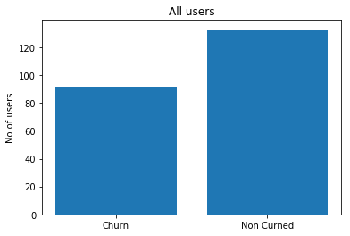

```python
plt.bar(['Churn','Non Curned'],[temp_df['userId'].nunique(),pd_clean_df['userId'].nunique()-temp_df['userId'].nunique() ])
plt.ylabel('No of users')
plt.title('All users')

plt.plot()
```

```
[]
```

[figure not shown]

```python
cancelled=pd_clean_df[pd_clean_df['page'] == 'Cancellation Confirmation'].shape[0]
downgraded=pd_clean_df[pd_clean_df['page'] == 'Submit Downgrade'].shape[0]

plt.bar(['cancellled service','downgraded service'],[cancelled,downgraded])
plt.ylabel('No of users')
plt.title('Total user churn')

plt.plot()
```

```python
#Creating new colunms for downgrade
# define a downgrade label
downgrade_value  = udf(lambda x: 1 if x == "Submit Downgrade" else 0, IntegerType())
clean_df = clean_df.withColumn("downgrade_value", downgrade_value("page"))

# define a churn label
churn_value = udf(lambda x: 1 if x == 'Cancellation Confirmation' else 0, IntegerType())
clean_df = clean_df.withColumn("churn_value", churn_value("page"))
```

```python
clean_df.select('userId','page','churn_value','downgrade_value').show(30)
```

```
+------+---------------+-----------+---------------+
|userId|           page|churn_value|downgrade_value|
+------+---------------+-----------+---------------+
|    30|       NextSong|          0|              0|
|     9|       NextSong|          0|              0|
|    30|       NextSong|          0|              0|
|     9|       NextSong|          0|              0|
|    30|       NextSong|          0|              0|
|     9|       NextSong|          0|              0|
|     9|       NextSong|          0|              0|
|    30|       NextSong|          0|              0|
|    30|Add to Playlist|          0|              0|
|    30|       NextSong|          0|              0|
|     9|       NextSong|          0|              0|
|     9|    Roll Advert|          0|              0|
|    30|       NextSong|          0|              0|
|     9|       NextSong|          0|              0|
|     9|      Thumbs Up|          0|              0|
|    30|       NextSong|          0|              0|
|     9|       NextSong|          0|              0|
|    74|       NextSong|          0|              0|
|    30|       NextSong|          0|              0|
|     9|       NextSong|          0|              0|
|    74|       NextSong|          0|              0|
|    30|       NextSong|          0|              0|
|    54|       NextSong|          0|              0|
|     9|       NextSong|          0|              0|
|    74|       NextSong|          0|              0|
|    30|       NextSong|          0|              0|
|    54|       NextSong|          0|              0|
|     9|       NextSong|          0|              0|
|    74|       NextSong|          0|              0|
|    30|       NextSong|          0|              0|
+------+---------------+-----------+---------------+
only showing top 30 rows
```

```python
#Updating each user which has churned as Y.
clean_df.select('userId','page','churn_value','downgrade_value').filter((clean_df.churn_value==1) | (clean_df.downgrade_value ==1) ).show(10)
```

```
+------+--------------------+-----------+---------------+
|userId|                page|churn_value|downgrade_value|
+------+--------------------+-----------+---------------+
|   131|    Submit Downgrade|          0|              1|
|    38|    Submit Downgrade|          0|              1|
|   141|    Submit Downgrade|          0|              1|
|    18|Cancellation Conf...|          1|              0|
|    30|    Submit Downgrade|          0|              1|
|    20|    Submit Downgrade|          0|              1|
|    32|Cancellation Conf...|          1|              0|
|    12|    Submit Downgrade|          0|              1|
|    11|    Submit Downgrade|          0|              1|
|    61|    Submit Downgrade|          0|              1|
+------+--------------------+-----------+---------------+
only showing top 10 rows
```

cCreating a colunm to identify user has churn , Basically marking all the entries of this user as churn if eventually customer has churned WE can do this in two ways,

1. using window function over records group by userID and if user has churn_value as 1 for any record we should mark it as churn
2. create udf , that take input as spark dataframe and userID, returns value as 1 if user has churned

```python
# find all users who downgraded
dg_window = Window.partitionBy('UserId')
clean_df = clean_df.withColumn("user_downgrade", max('downgrade_value').over(dg_window))
clean_df = clean_df.withColumn("user_cancle", max('churn_value').over(dg_window))
```

```python
chrun=udf(lambda x,y: x|y, IntegerType())
clean_df = clean_df.withColumn("user_churn", chrun("user_cancle","user_downgrade"))
```

```python
#clean_df.drop('user_churn')
```

```python
clean_df.select(['userId', 'firstName', 'level','user_churn', 'user_downgrade','user_cancle']).dropDuplicates(subset = ['userId']).show(20)
```

```
+------+---------+-----+----------+--------------+-----------+
|userId|firstName|level|user_churn|user_downgrade|user_cancle|
+------+---------+-----+----------+--------------+-----------+
|100010| Darianna| free|         0|             0|          0|
|200002|  Dominic| free|         0|             0|          0|
|   125|    Mason| free|         1|             0|          1|
|   124|   Nicole| paid|         0|             0|          0|
|    51|    Ethan| paid|         1|             0|          1|
|     7|   Maddox| free|         0|             0|          0|
|    15|    Panav| paid|         0|             0|          0|
|    54|    Alexi| paid|         1|             1|          1|
|   155|   Camila| free|         0|             0|          0|
|100014|  Rodrigo| paid|         1|             0|          1|
|   132|    Sadie| free|         0|             0|          0|
|   154|   Morgan| free|         0|             0|          0|
|   101|     Alex| free|         1|             0|          1|
|    11|      Zoe| free|         1|             1|          0|
|   138|   Samuel| free|         0|             0|          0|
|300017|  Alyssia| paid|         0|             0|          0|
|100021|   Rayden| free|         1|             0|          1|
|    29|    Kaleb| free|         1|             0|          1|
|    69|     Jada| free|         0|             0|          0|
|   112|    Logan| free|         0|             0|          0|
+------+---------+-----+----------+--------------+-----------+
only showing top 20 rows
```

```python
clean_df.select(['userId', 'firstName', 'level','user_churn', 'user_downgrade','user_cancle']).filter((clean_df.user_downgrade ==1)& (clean_df.user_cancle ==0) ).dropDuplicates(subset = ['userId']).show(30)
```

```
+------+----------+-----+----------+--------------+-----------+
|userId| firstName|level|user_churn|user_downgrade|user_cancle|
+------+----------+-----+----------+--------------+-----------+
|    11|       Zoe| free|         1|             1|          0|
|    30|     Colin| paid|         1|             1|          0|
|    59|    Jaleel| free|         1|             1|          0|
|    85|   Brayden| free|         1|             1|          0|
|    35|      Lily| free|         1|             1|          0|
|100008|   Bryanna| paid|         1|             1|          0|
|300002|    Lindyn| free|         1|             1|          0|
|    96|Alexandria| paid|         1|             1|          0|
|   100|     Colin| paid|         1|             1|          0|
|    61|    Parker| free|         1|             1|          0|
|   131|      Kael| free|         1|             1|          0|
|   140|    Lucero| free|         1|             1|          0|
|300004|    Peyton| free|         1|             1|          0|
|300015|    Joshua| free|         1|             1|          0|
|    77|    Autumn| paid|         1|             1|          0|
|300011|    Emilia| free|         1|             1|          0|
|100004|     Emily| free|         1|             1|          0|
|200003|      Zoey| paid|         1|             1|          0|
|300023|     Chloe| paid|         1|             1|          0|
|100016|    Landon| paid|         1|             1|          0|
|    95|     Faigy| paid|         1|             1|          0|
|    38|    Calvin| paid|         1|             1|          0|
|200009|  Benjamin| free|         1|             1|          0|
|    25|   Madison| paid|         1|             1|          0|
|200023|   Katiana| free|         1|             1|          0|
|    92|     Riley| free|         1|             1|          0|
|    81|    Oliver| paid|         1|             1|          0|
|200025|     Elias| free|         1|             1|          0|
|   141|   Kaylenn| paid|         1|             1|          0|
|    24|   Garrett| free|         1|             1|          0|
+------+----------+-----+----------+--------------+-----------+
only showing top 30 rows
```

```python
df_ch_pd = clean_df.drop_duplicates(['userId', 'gender']).groupby(['user_churn', 'gender']).count().sort("user_churn").toPandas()
```

```python
df_ch_pd
```

|  | user_churn | gender | count |
| --- | --- | --- | --- |
| 0 | 0 | M | 72 |
| 1 | 0 | F | 61 |
| 2 | 1 | F | 43 |
| 3 | 1 | M | 49 |

as both male & female as churned and with more or less same percentge of users getting churn it may not be deciding factor in churn

```python
clean_df.createOrReplaceTempView("sparkify")
```

```python
query=spark.sql("select user_churn,avg(itemInSession) from sparkify group by user_churn")
query.show()
```

```
+----------+------------------+
|user_churn|avg(itemInSession)|
+----------+------------------+
|         1|108.24558629776021|
|         0|121.68204357516753|
+----------+------------------+
```

```python
temp_pd=query.toPandas()
```

```python
temp_pd
```

|  | user_churn | avg(itemInSession) |
| --- | --- | --- |
| 0 | 1 | 108.245586 |
| 1 | 0 | 121.682044 |

```
[]
```

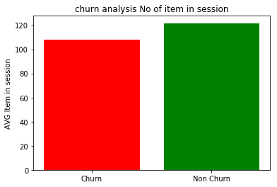

```python
plt.bar(['Churn','Non Churn'],temp_pd['avg(itemInSession)'],color=['red','green'])
plt.ylabel('AVG Item in session')
plt.title('churn analysis No of item in session')

plt.plot()
```

We can see churn users has less item in a session,indicating less songs played

```python
#'user_downgrade','user_cancle'
query=spark.sql("select user_downgrade,user_cancle,avg(itemInSession) from sparkify group by user_downgrade,user_cancle")
query.show()
```

```
+--------------+-----------+------------------+
|user_downgrade|user_cancle|avg(itemInSession)|
+--------------+-----------+------------------+
|             1|          0|107.78196983809693|
|             1|          1|100.47941626880461|
|             0|          0|121.68204357516753|
|             0|          1|112.11109794745728|
+--------------+-----------+------------------+
```

```python
temp_pd=query.toPandas()
```

```python
temp_pd
```

|  | user_downgrade | user_cancle | avg(itemInSession) |
| --- | --- | --- | --- |
| 0 | 1 | 0 | 107.781970 |
| 1 | 1 | 1 | 100.479416 |
| 2 | 0 | 0 | 121.682044 |
| 3 | 0 | 1 | 112.111098 |

```
[]
```

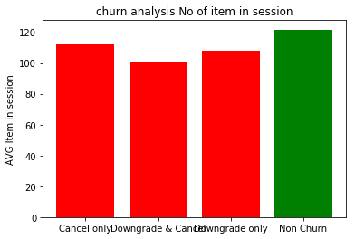

```python
plt.bar(['Downgrade only','Downgrade & Cancel','Non Churn','Cancel only'],temp_pd['avg(itemInSession)'],color=['red','red','green','red'])
plt.ylabel('AVG Item in session')
plt.title('churn analysis No of item in session')
plt.legend()
plt.plot()
```

Are paid user are downgrading more or voerall user are cancelling the service

```python
query = spark.sql("select user_downgrade,user_cancle,count(distinct (userId)) from sparkify group by user_downgrade,user_cancle")
temp_pd=query.toPandas()
temp_pd
```

|  | user_downgrade | user_cancle | count(DISTINCT userId) |
| --- | --- | --- | --- |
| 0 | 1 | 0 | 40 |
| 1 | 1 | 1 | 9 |
| 2 | 0 | 0 | 133 |
| 3 | 0 | 1 | 43 |

[figure not shown]

```python
plt.bar(['Downgrade only','Downgrade & Cancel','Non Churn','Cancel only'],temp_pd['count(DISTINCT userId)'],color=['red','red','green','red'])
plt.ylabel('AVG Item in session')
plt.title('churn analysis ')
plt.legend()
plt.show()
```

Are paid user more chruning ?

```python
#level|user_churn
query=spark.sql("select level,user_churn,count(distinct userID) from sparkify group by level,user_churn")
query.show()
```

```
+-----+----------+----------------------+
|level|user_churn|count(DISTINCT userID)|
+-----+----------+----------------------+
| paid|         0|                    89|
| free|         0|                   109|
| paid|         1|                    76|
| free|         1|                    86|
+-----+----------+----------------------+
```

```python
query=spark.sql("select user_downgrade,user_cancle,level,user_churn,count(distinct userID) from sparkify group by level,user_churn,user_downgrade,user_cancle")
query.show()
```

```
+--------------+-----------+-----+----------+----------------------+
|user_downgrade|user_cancle|level|user_churn|count(DISTINCT userID)|
+--------------+-----------+-----+----------+----------------------+
|             1|          1| free|         1|                     9|
|             1|          0| free|         1|                    40|
|             0|          0| free|         0|                   109|
|             1|          1| paid|         1|                     9|
|             1|          0| paid|         1|                    40|
|             0|          0| paid|         0|                    89|
|             0|          1| paid|         1|                    27|
|             0|          1| free|         1|                    37|
+--------------+-----------+-----+----------+----------------------+
```

```python
query.select('count(DISTINCT userID)').where((query.level =='free') & (query.user_churn == 0)).show()
```

```
+----------------------+
|count(DISTINCT userID)|
+----------------------+
|                   109|
+----------------------+
```

```python
paid_churn_precentage= 76/(89+76)
free_churn_precentage= 86/(86+109)
```

```python
paid_churn_precentage
```

```
0.46060606060606063
```

```python
free_churn_precentage
```

```
0.441025641025641
```

```
[]
```

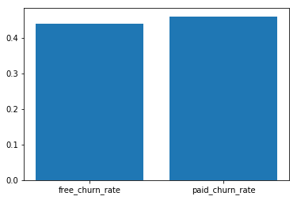

```python
plt.bar(['paid_churn_rate','free_churn_rate'],[paid_churn_precentage,free_churn_precentage])
plt.plot()
```

```python
query=spark.sql("select user_churn,count(song) from sparkify group by user_churn")
query.show()
```

```
+----------+-----------+
|user_churn|count(song)|
+----------+-----------+
|         1|     114545|
|         0|     113563|
+----------+-----------+
```

```python
query=spark.sql("select user_churn,avg(length) from sparkify group by user_churn")
query.show()
```

```
+----------+------------------+
|user_churn|       avg(length)|
+----------+------------------+
|         1|249.10222253882736|
|         0|249.13227077384346|
+----------+------------------+
```

```python
query=spark.sql("select user_churn,count(distinct userId) from sparkify where page ='Submit Upgrade' group by user_churn")
query.show()
```

```
+----------+----------------------+
|user_churn|count(DISTINCT userId)|
+----------+----------------------+
|         1|                    66|
|         0|                    65|
+----------+----------------------+
```

```python
churn_value = udf(lambda x: 1 if x == 'Submit Upgrade' else 0, IntegerType())
clean_df = clean_df.withColumn("upgraded", churn_value("page"))
```

```python
dg_window = Window.partitionBy('UserId')
clean_df = clean_df.withColumn("user_upgraded", max('upgraded').over(dg_window))
```

```python
clean_df.createOrReplaceTempView("sparkify")
```

```python
query=spark.sql("select user_churn,count(distinct userId) from sparkify where user_upgraded =1 group by user_churn")
query.show()
temp_df=query.toPandas()
```

```
+----------+----------------------+
|user_churn|count(DISTINCT userId)|
+----------+----------------------+
|         1|                    66|
|         0|                    65|
+----------+----------------------+
```

```
[]
```

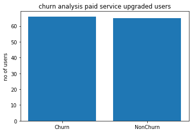

```python
plt.bar(['Churn','NonChurn'],temp_df['count(DISTINCT userId)'])
plt.ylabel('no of users')
plt.title('churn analysis paid service upgraded users')
plt.legend()
plt.plot()
```

```
+----------+----------------------+
|user_churn|count(DISTINCT userId)|
+----------+----------------------+
|         1|                    26|
|         0|                    68|
+----------+----------------------+
```

```
[]
```

[figure not shown]

```python
query=spark.sql("select user_churn,count(distinct userId) from sparkify where user_upgraded =0 group by user_churn")
query.show()
temp_df=query.toPandas()
plt.bar(['Churn','NonChurn'],temp_df['count(DISTINCT userId)'])
plt.ylabel('no of users')
plt.title('churn analysis paid service upgraded users')
plt.legend()
plt.plot()
```

```python
query=spark.sql("select user_churn,user_upgraded,count(distinct userId) from sparkify group by user_churn,user_upgraded")
query.show()
```

```
+----------+-------------+----------------------+
|user_churn|user_upgraded|count(DISTINCT userId)|
+----------+-------------+----------------------+
|         1|            0|                    26|
|         1|            1|                    66|
|         0|            0|                    68|
|         0|            1|                    65|
+----------+-------------+----------------------+
```

As 50% of user churned after upgrading thier services to paid subscription this is important feature

```python
query=spark.sql("select user_churn,count(*) from sparkify where page ='Thumbs Down' group by user_churn")
query.show()
```

```
+----------+--------+
|user_churn|count(1)|
+----------+--------+
|         1|    1401|
|         0|    1145|
+----------+--------+
```

```python
print ("Average thumbbs down per user for churn user : ", 1401/92)
print ("Average thumbbs down per user for non churn user : ", 1145/(225-92))
```

```
Average thumbbs down per user for churn user :  15.228260869565217
Average thumbbs down per user for non churn user :  8.609022556390977
```

Churn users even though smaller in number has more thumbs down indicating poor service performance

```python
query=spark.sql("select user_churn,count(*) from sparkify where page ='Thumbs Up' group by user_churn")
query.show()
```

```
+----------+--------+
|user_churn|count(1)|
+----------+--------+
|         1|    6294|
|         0|    6257|
+----------+--------+
```

```python
print ("Average thumbbs up per user for churn user : ", 6294/92)
print ("Average thumbbs up per user for non churn user : ", 6257/(225-92))
```

```
Average thumbbs up per user for churn user :  68.41304347826087
Average thumbbs up per user for non churn user :  47.045112781954884
```

Although thumbs up are also higher for churn, this may be contradict . but still importat feature to consider

```python
query=spark.sql("select user_churn,count(*) from sparkify where page ='Error' group by user_churn")
query.show()
```

```
+----------+--------+
|user_churn|count(1)|
+----------+--------+
|         1|     112|
|         0|     140|
+----------+--------+
```

```python
print ("Average error per user for churn user : ", 112/92)
print ("Average error per user for non churn user : ", 140/(225-92))
```

```
Average error per user for churn user :  1.2173913043478262
Average error per user for non churn user :  1.0526315789473684
```

More errors for churn user indicating poor quality may lead to churn

```python
query=spark.sql("select count(sessionId),user_churn from sparkify group by user_churn")
query.show()
```

```
+----------------+----------+
|count(sessionId)|user_churn|
+----------------+----------+
|          140415|         1|
|          137739|         0|
+----------------+----------+
```

```python
#Save Settings
query=spark.sql("select count(*),user_churn from sparkify where page='Save Settings' group by user_churn")
query.show()
```

```
+--------+----------+
|count(1)|user_churn|
+--------+----------+
|     145|         1|
|     165|         0|
+--------+----------+
```

```python
print ("Average Settings change per user for churn user : ", 145/92)
print ("Average Settings change per user for non churn user : ", 165/(225-92))
```

```
Average Settings change per user for churn user :  1.576086956521739
Average Settings change per user for non churn user :  1.2406015037593985
```

More settings change by churn user may indicate lack or usablity of service

# Feature Engineering

Once you've familiarized yourself with the data, build out the features you find promising to train your model on. To work with the full dataset, you can follow the following steps.

- Write a script to extract the necessary features from the smaller subset of data
- Ensure that your script is scalable, using the best practices discussed in Lesson 3
- Try your script on the full data set, debugging your script if necessary

If you are working in the classroom workspace, you can just extract features based on the small subset of data contained here. Be sure to transfer over this work to the larger dataset when you work on your Spark cluster.

Based on data analysis done in earlier session. below are important features

1. positive indicators
   1. Number of thumbs up
      - If user has thumps up then they have liked the then its positive single they liked the serive
   2. Number of songs played
   3. Number of artist played
   4. Number of friends recommended
      - If user has recommended service to user
   5. Number of songs added to playlist
   6. upgrade to paid service
2. Negative indicators
   1. Number of thumbs down
   2. Number of error received
   3. Number of help call received
   4. Number of settings changed
3. Independent indicators
   1. Gender
   2. No of sessions

There will be users which will not have few features, since all the features listed above are of type integers so default value is 0 for any user missing these features.

Now to add these missing users into dataframe I followed below steps for each new feature added

- step1 prepare list of all users
- step2 create function that will create spark dataframe with userid & 0
- step3 create dataframe with userID & feature of interest
- step4 check if all users are present in dataset or not, if not call function created in step 2 and create new dataframe.
- step4 append newly createed dataframe witch existing dataframe

```python
total_users=clean_df.select('userId').drop_duplicates().collect()
```

```python
length=len(total_users)
uId_list=[]
for i in range(length):
    uId_list.append(total_users[i].userId)
```

```python
def add_new_row(all_users,feat_df):
    uId= feat_df.select('userId').collect()
    length=len(uId)
    users=[]
    for i in range(length):
        users.append(uId[i].userId)

    new_df_list=[]
    for u in all_users:
        if u not in users:
            row=[u,0]
            new_df_list.append(row)
    new_df=spark.createDataFrame(new_df_list)
    feat_df=feat_df.union(new_df)
    return feat_df
```

```python
#1A Number of thumbs up
```

```python
feat_1 = clean_df.select('userId', 'page').where(df.page == 'Thumbs Up').groupBy('userId').count().withColumnRenamed('count', 'tot_thumbs_up')
feat_1.show()
feat_1.count()
```

```
+------+-------------+
|userId|tot_thumbs_up|
+------+-------------+
|100010|           17|
|200002|           21|
|    51|          100|
|   124|          171|
|     7|            7|
|    54|          163|
|    15|           81|
|   155|           58|
|   132|           96|
|   154|           11|
|100014|           17|
|   101|           86|
|    11|           40|
|   138|           95|
|300017|          303|
|    29|          154|
|    69|           72|
|100021|           11|
|    42|          166|
|   112|            9|
+------+-------------+
only showing top 20 rows
```

```
220
```

5 users are missing from list

```python
feat_1=add_new_row(uId_list,feat_1)
```

```python
feat_1.count()
```

```
225
```

```python
#1B Number songs played
feat_2 = clean_df.select('userId', 'song').groupBy('userId').count().withColumnRenamed('count', 'tot_songs')
feat_2.show()
```

```
+------+---------+
|userId|tot_songs|
+------+---------+
|100010|      381|
|200002|      474|
|   125|       11|
|    51|     2464|
|   124|     4825|
|     7|      201|
|    54|     3437|
|    15|     2278|
|   155|     1002|
|   132|     2304|
|   154|      118|
|100014|      310|
|   101|     2149|
|    11|      848|
|   138|     2469|
|300017|     4428|
|    29|     3603|
|    69|     1342|
|100021|      319|
|    42|     4257|
+------+---------+
only showing top 20 rows
```

```python
feat_2=spark.sql("select userID,count(song) tot_songs from sparkify where song is not null group by userId")
feat_2.show()
feat_2.count()
```

```
+------+---------+
|userID|tot_songs|
+------+---------+
|100010|      275|
|200002|      387|
|   125|        8|
|    51|     2111|
|   124|     4079|
|     7|      150|
|    54|     2841|
|    15|     1914|
|   155|      820|
|   132|     1928|
|   154|       84|
|100014|      257|
|   101|     1797|
|    11|      647|
|   138|     2070|
|300017|     3632|
|    29|     3028|
|    69|     1125|
|100021|      230|
|    42|     3573|
+------+---------+
only showing top 20 rows
```

```
225
```

```python
#1C Number of artist played
feat_3 = clean_df.select('userId', 'artist').groupBy('userId').count().withColumnRenamed('count', 'tot_artist')
feat_3.show()
feat_3.count()
```

```
+------+----------+
|userId|tot_artist|
+------+----------+
|100010|       381|
|200002|       474|
|   125|        11|
|    51|      2464|
|   124|      4825|
|     7|       201|
|    54|      3437|
|    15|      2278|
|   155|      1002|
|   132|      2304|
|   154|       118|
|100014|       310|
|   101|      2149|
|    11|       848|
|   138|      2469|
|300017|      4428|
|    29|      3603|
|    69|      1342|
|100021|       319|
|    42|      4257|
+------+----------+
only showing top 20 rows
```

```
225
```

```python
feat_3=spark.sql("select userID,count(artist) tot_artist from sparkify where artist is not null group by userId")
feat_3.show()
feat_3.count()
```

```
+------+----------+
|userID|tot_artist|
+------+----------+
|100010|       275|
|200002|       387|
|   125|         8|
|    51|      2111|
|   124|      4079|
|     7|       150|
|    54|      2841|
|    15|      1914|
|   155|       820|
|   132|      1928|
|   154|        84|
|100014|       257|
|   101|      1797|
|    11|       647|
|   138|      2070|
|300017|      3632|
|    29|      3028|
|    69|      1125|
|100021|       230|
|    42|      3573|
+------+----------+
only showing top 20 rows
```

```
225
```

```python
#1d Number of friends recommended
feat_4=spark.sql("select userID,count(*) tot_friends from sparkify where page='Add Friend'  group by userId")
feat_4.show()
feat_4.count()
```

```
+------+-----------+
|userID|tot_friends|
+------+-----------+
|100010|          4|
|200002|          4|
|    51|         28|
|   124|         74|
|     7|          1|
|    54|         33|
|    15|         31|
|   155|         11|
|   132|         41|
|   154|          3|
|100014|          6|
|   101|         29|
|    11|          6|
|   138|         41|
|300017|         63|
|    29|         47|
|    69|         12|
|100021|          7|
|    42|         52|
|   112|          7|
+------+-----------+
only showing top 20 rows
```

```
206
```

```python
feat_4=add_new_row(uId_list,feat_4)
feat_4.count()
```

```
225
```

```python
#1E Number of songs added to playlist
feat_5=spark.sql("select userID,count(*) tot_playlist from sparkify where page='Add to Playlist'  group by userId")
feat_5.show()
feat_5.count()
```

```
+------+------------+
|userID|tot_playlist|
+------+------------+
|100010|           7|
|200002|           8|
|    51|          52|
|   124|         118|
|     7|           5|
|    15|          59|
|    54|          72|
|   155|          24|
|   132|          38|
|   154|           1|
|100014|           7|
|   101|          61|
|    11|          20|
|   138|          67|
|300017|         113|
|    29|          89|
|    69|          33|
|100021|           7|
|    42|         104|
|   112|           7|
+------+------------+
only showing top 20 rows
```

```
215
```

```python
feat_5=add_new_row(uId_list,feat_5)
feat_5.count()
```

```
225
```

```python
#upgrade to paid service
feat_6=spark.sql("select distinct(userID), user_upgraded from sparkify")
feat_6.show()
feat_6.count()
```

```
+------+-------------+
|userID|user_upgraded|
+------+-------------+
|100010|            0|
|200002|            1|
|   125|            0|
|   124|            0|
|    51|            0|
|     7|            0|
|    15|            0|
|    54|            1|
|   155|            1|
|100014|            0|
|   132|            1|
|   154|            0|
|   101|            1|
|    11|            1|
|   138|            1|
|300017|            0|
|100021|            0|
|    29|            1|
|    69|            1|
|   112|            0|
+------+-------------+
only showing top 20 rows
```

```
225
```

```python
#2A Number of thumbs down
feat_2A=spark.sql("select userID,count(*) tot_thumb_down from sparkify where page ='Thumbs Down' group by userID")
feat_2A.show()
feat_2A.count()
```

```
+------+--------------+
|userID|tot_thumb_down|
+------+--------------+
|100010|             5|
|200002|             6|
|    51|            21|
|   124|            41|
|     7|             1|
|    15|            14|
|    54|            29|
|   155|             3|
|   132|            17|
|100014|             3|
|   101|            16|
|    11|             9|
|   138|            24|
|300017|            28|
|    29|            22|
|    69|             9|
|100021|             5|
|    42|            25|
|   112|             3|
|    73|             7|
+------+--------------+
only showing top 20 rows
```

```
203
```

```python
feat_2A=add_new_row(uId_list,feat_2A)
feat_2A.count()
```

```
225
```

```python
#2B Number of error received Error
feat_2B=spark.sql("select userID,count(*) tot_errs from sparkify where page ='Error' group by userID")
feat_2B.show()
feat_2B.count()
```

```
+------+--------+
|userID|tot_errs|
+------+--------+
|   124|       6|
|    51|       1|
|     7|       1|
|    15|       2|
|    54|       1|
|   155|       3|
|   132|       3|
|   101|       3|
|    11|       1|
|   138|       1|
|300017|       5|
|    69|       4|
|100021|       2|
|    42|       7|
|    73|       1|
|200010|       1|
|    30|       1|
|   113|       3|
|    59|       4|
|   146|       1|
+------+--------+
only showing top 20 rows
```

```
117
```

```python
feat_2B=add_new_row(uId_list,feat_2B)
feat_2B.count()
```

```
225
```

```python
#2C Number of help call received
feat_2C=spark.sql("select userID,count(*) tot_help from sparkify where page ='Help' group by userID")
feat_2C.show()
feat_2C.count()
```

```
+------+--------+
|userID|tot_help|
+------+--------+
|100010|       2|
|200002|       2|
|    51|      12|
|   124|      23|
|     7|       1|
|    54|      17|
|    15|       8|
|   155|       9|
|   132|      16|
|   154|       1|
|100014|       2|
|   101|      12|
|    11|       3|
|   138|      13|
|300017|      27|
|    29|      28|
|    69|       7|
|   112|       1|
|    42|      20|
|    73|       4|
+------+--------+
only showing top 20 rows
```

```
192
```

```python
feat_2C=add_new_row(uId_list,feat_2C)
feat_2C.count()
```

```
225
```

```python
#2D Number of settings changed
feat_2D=spark.sql("select userID,count(*) tot_setting from sparkify where page ='Save Settings' group by userID")
feat_2D.show()
feat_2D.count()
```

```
+------+-----------+
|userID|tot_setting|
+------+-----------+
|    51|          1|
|   124|          6|
|     7|          1|
|    15|          2|
|    54|          3|
|   132|          4|
|    11|          2|
|   101|          2|
|   138|          4|
|300017|          3|
|    29|          4|
|    69|          1|
|   112|          3|
|    42|          7|
|    73|          1|
|   113|          3|
|    30|          1|
|300018|          2|
|300012|          1|
|100022|          2|
+------+-----------+
only showing top 20 rows
```

```
132
```

```python
feat_2D=add_new_row(uId_list,feat_2D)
feat_2D.count()
```

```
225
```

```python
#3A Gender of user
feat_3A = spark.sql("select distinct(userID),gender from sparkify")
feat_3A.show()
```

```
+------+------+
|userID|gender|
+------+------+
|    44|     F|
|    46|     F|
|    41|     F|
|    72|     F|
|300023|     F|
|    39|     F|
|100010|     F|
|    40|     F|
|    94|     F|
|    35|     F|
|    75|     F|
|   116|     F|
|200001|     M|
|200020|     M|
|100008|     F|
|200015|     M|
|   100|     M|
|100006|     F|
|300005|     F|
|    25|     F|
+------+------+
only showing top 20 rows
```

```python
feat_3A=feat_3A.replace(['F', 'M'], ['0', '1'], 'gender').select('userId', col('gender').cast('int'))
feat_3A.show()
```

```
+------+------+
|userId|gender|
+------+------+
|    44|     0|
|    46|     0|
|    41|     0|
|    72|     0|
|300023|     0|
|    39|     0|
|100010|     0|
|    40|     0|
|    94|     0|
|    35|     0|
|    75|     0|
|   116|     0|
|200001|     1|
|200020|     1|
|100008|     0|
|200015|     1|
|   100|     1|
|100006|     0|
|300005|     0|
|    25|     0|
+------+------+
only showing top 20 rows
```

```python
# Total length of listening utilizing all services
feat_3B = df.select("userId", 'length').groupBy('userId').sum().withColumnRenamed('sum(length)', 'tot_listen_time').dropDuplicates()
feat_3B.show()
feat_3B.count()
```

```
+------+------------------+
|userId|   tot_listen_time|
+------+------------------+
|100010| 66940.89735000003|
|200002| 94008.87593999993|
|   125|2089.1131000000005|
|    51| 523275.8428000004|
|   124|1012312.0927899999|
|     7| 38034.08710000002|
|    54| 711344.9195400011|
|    15|477307.60581000015|
|   155|       198779.2919|
|   132| 483118.9038399997|
|   154|20660.023910000007|
|100014| 67703.47208000004|
|   101| 447464.0146699989|
|    11|159669.96303999983|
|   138| 512449.8827599989|
|300017| 897406.9802100015|
|    29| 754517.5625700009|
|    69| 286064.0256399999|
|100021| 57633.17563999999|
|    42| 881792.9661300007|
+------+------------------+
only showing top 20 rows
```

```
226
```

```python
feat_3C = df.select('userId', 'registration', 'ts').withColumn('tot_lifetime', (df.ts - df.registration))\
    .groupBy('userId').agg({'tot_lifetime' : 'max'})\
    .withColumnRenamed('max(tot_lifetime)', 'tot_lifetime')\
    .select('userId', (col('tot_lifetime')/1000/3600/24).alias('tot_lifetime'))
feat_3C.show()
```

```
+------+------------------+
|userId|      tot_lifetime|
+------+------------------+
|100010|  55.6436574074074|
|200002| 70.07462962962963|
|   125| 71.31688657407408|
|    51|19.455844907407407|
|   124|131.55591435185184|
|     7| 72.77818287037037|
|    54|110.75168981481481|
|    15|56.513576388888886|
|   155|23.556018518518517|
|   132|  66.8891087962963|
|   154|23.872037037037035|
|100014| 85.08340277777778|
|   101|53.965937499999995|
|    11|124.47825231481481|
|   138| 66.62668981481481|
|300017| 74.35851851851852|
|    29|60.104050925925925|
|    69| 71.42444444444445|
|100021| 64.73886574074074|
|    42| 67.11364583333334|
+------+------------------+
only showing top 20 rows
```

```python
feat_4A=spark.sql("select distinct(userId),user_cancle from sparkify")
feat_4A.show()
feat_4A.count()
```

```
+------+-----------+
|userId|user_cancle|
+------+-----------+
|100010|          0|
|200002|          0|
|   125|          1|
|   124|          0|
|    51|          1|
|     7|          0|
|    15|          0|
|    54|          1|
|   155|          0|
|100014|          1|
|   132|          0|
|   154|          0|
|   101|          1|
|    11|          0|
|   138|          0|
|300017|          0|
|100021|          1|
|    29|          1|
|    69|          0|
|   112|          0|
+------+-----------+
only showing top 20 rows
```

```
225
```

```python
feat_4B=spark.sql("select distinct(userId),user_downgrade from sparkify")
feat_4B.show()
feat_4B.count()
```

```
+------+--------------+
|userId|user_downgrade|
+------+--------------+
|100010|             0|
|200002|             0|
|   125|             0|
|   124|             0|
|    51|             0|
|     7|             0|
|    15|             0|
|    54|             1|
|   155|             0|
|100014|             0|
|   132|             0|
|   154|             0|
|   101|             0|
|    11|             1|
|   138|             0|
|300017|             0|
|100021|             0|
|    29|             0|
|    69|             0|
|   112|             0|
+------+--------------+
only showing top 20 rows
```

```
225
```

```python
target = clean_df.select('userId', col('user_churn').alias('target')).dropDuplicates()
target.show()
target.count()
```

```
+------+------+
|userId|target|
+------+------+
|    19|     0|
|300007|     1|
|100005|     1|
|200007|     0|
|200002|     0|
|    25|     1|
|    50|     0|
|     8|     0|
|100011|     1|
|100012|     1|
|     4|     0|
|    65|     0|
|   101|     1|
|300015|     1|
|   153|     0|
|100014|     1|
|    42|     0|
|    62|     0|
|    94|     0|
|   114|     0|
+------+------+
only showing top 20 rows
```

```
225
```

```python
final_data = feat_1.join(feat_2, 'userId', 'inner').join(feat_3, 'userId', 'inner').join(feat_4, 'userId', 'inner')\
             .join(feat_5, 'userId', 'inner').join(feat_6, 'userId', 'inner').join(feat_2A, 'userId', 'inner').join(feat_2B, 'userId', 'inner')\
             .join(feat_2C, 'userId', 'inner').join(feat_2D, 'userId', 'inner').join(feat_3A, 'userId', 'inner').join(feat_3B, 'userId', 'inner').join(feat_3C, 'userId', 'inner').join(feat_4A, 'userId', 'inner').join(feat_4B, 'userId', 'inner').join(target, 'userId', 'inner').drop('userId')

final_data.show()
```

```
+-------------+---------+----------+-----------+------------+-------------+--------------+--------+--------+-----------+------+------------------+------------------+-----------+--------------+------+
|tot_thumbs_up|tot_songs|tot_artist|tot_friends|tot_playlist|user_upgraded|tot_thumb_down|tot_errs|tot_help|tot_setting|gender|   tot_listen_time|      tot_lifetime|user_cancle|user_downgrade|target|
+-------------+---------+----------+-----------+------------+-------------+--------------+--------+--------+-----------+------+------------------+------------------+-----------+--------------+------+
|           17|      275|       275|          4|           7|            0|             5|       0|       2|          0|     0| 66940.89735000003|  55.6436574074074|          0|             0|     0|
|           21|      387|       387|          4|           8|            1|             6|       0|       2|          0|     1| 94008.87593999993| 70.07462962962963|          0|             0|     0|
|            0|        8|         8|          0|           0|            0|             0|       0|       0|          0|     1|2089.1131000000005| 71.31688657407408|          1|             0|     1|
|          171|     4079|      4079|         74|         118|            0|            41|       6|      23|          6|     0|1012312.0927899999|131.55591435185184|          0|             0|     0|
|          100|     2111|      2111|         28|          52|            0|            21|       1|      12|          1|     1| 523275.8428000004|19.455844907407407|          1|             0|     1|
|            7|      150|       150|          1|           5|            0|             1|       1|       1|          1|     1| 38034.08710000002| 72.77818287037037|          0|             0|     0|
|           81|     1914|      1914|         31|          59|            0|            14|       2|       8|          2|     1|477307.60581000015|56.513576388888886|          0|             0|     0|
|          163|     2841|      2841|         33|          72|            1|            29|       1|      17|          3|     0| 711344.9195400011|110.75168981481481|          1|             1|     1|
|           58|      820|       820|         11|          24|            1|             3|       3|       9|          0|     0|       198779.2919|23.556018518518517|          0|             0|     0|
|           17|      257|       257|          6|           7|            0|             3|       0|       2|          0|     1| 67703.47208000004| 85.08340277777778|          1|             0|     1|
|           96|     1928|      1928|         41|          38|            1|            17|       3|      16|          4|     0| 483118.9038399997|  66.8891087962963|          0|             0|     0|
|           11|       84|        84|          3|           1|            0|             0|       0|       1|          0|     0|20660.023910000007|23.872037037037035|          0|             0|     0|
|           86|     1797|      1797|         29|          61|            1|            16|       3|      12|          2|     1| 447464.0146699989|53.965937499999995|          1|             0|     1|
|           40|      647|       647|          6|          20|            1|             9|       1|       3|          2|     0|159669.96303999983|124.47825231481481|          0|             1|     1|
|           95|     2070|      2070|         41|          67|            1|            24|       1|      13|          4|     1| 512449.8827599989| 66.62668981481481|          0|             0|     0|
|          303|     3632|      3632|         63|         113|            0|            28|       5|      27|          3|     0| 897406.9802100015| 74.35851851851852|          0|             0|     0|
|           11|      230|       230|          7|           7|            0|             5|       2|       0|          0|     1| 57633.17563999999| 64.73886574074074|          1|             0|     1|
|          154|     3028|      3028|         47|          89|            1|            22|       0|      28|          4|     1| 754517.5625700009|60.104050925925925|          1|             0|     1|
|           72|     1125|      1125|         12|          33|            1|             9|       4|       7|          1|     0| 286064.0256399999| 71.42444444444445|          0|             0|     0|
|            9|      215|       215|          7|           7|            0|             3|       0|       1|          3|     1| 53062.74659000002| 87.46262731481481|          0|             0|     0|
+-------------+---------+----------+-----------+------------+-------------+--------------+--------+--------+-----------+------+------------------+------------------+-----------+--------------+------+
only showing top 20 rows
```

```python
final_data.count()
```

```
225
```

```python
clean_df.select('userID').drop_duplicates().count()
```

```
225
```

```python
#final_data.describe()
```

```python
#final_data.describe().select("Summary","tot_thumbs_up","tot_songs","tot_artist","tot_thumb_down","tot_errs").show()
```

```python
pd_final=final_data.toPandas()
```

```python
#pd_final.describe()
```

```python
non_churn =pd_final[pd_final['target'] == 0].shape[0]
```

```python
churn=pd_final[pd_final['target'] == 1].shape[0]
```

```
 [Text(-0.310576,1.05525,'non_churn'), Text(0.310576,-1.05525,'churn')])
```

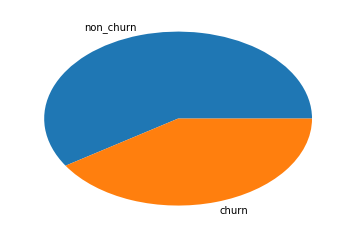

```python
plt.pie([non_churn,churn],labels=['non_churn','churn'],)
```

# Modeling

Split the full dataset into train, test, and validation sets. Test out several of the machine learning methods you learned. Evaluate the accuracy of the various models, tuning parameters as necessary. Determine your winning model based on test accuracy and report results on the validation set. Since the churned users are a fairly small subset, I suggest using F1 score as the metric to optimize.

```python
#combine all the features in one single feature vector.
cols=final_data.columns
```

```python
cols
```

```
['tot_thumbs_up',
 'tot_songs',
 'tot_artist',
 'tot_friends',
 'tot_playlist',
 'user_upgraded',
 'tot_thumb_down',
 'tot_errs',
 'tot_help',
 'tot_setting',
 'gender',
 'tot_listen_time',
 'tot_lifetime',
 'user_cancle',
 'user_downgrade',
 'target']
```

```python
cols.remove('target')
```

```python
assembler = VectorAssembler(inputCols=cols,outputCol="features")
# Now let us use the transform method to transform our dataset
final_data=assembler.transform(final_data)
final_data.select("features").show()
```

```
+--------------------+
|            features|
+--------------------+
|[17.0,275.0,275.0...|
|[21.0,387.0,387.0...|
|(15,[1,2,10,11,12...|
|[171.0,4079.0,407...|
|[100.0,2111.0,211...|
|[7.0,150.0,150.0,...|
|[81.0,1914.0,1914...|
|[163.0,2841.0,284...|
|[58.0,820.0,820.0...|
|[17.0,257.0,257.0...|
|[96.0,1928.0,1928...|
|(15,[0,1,2,3,4,8,...|
|[86.0,1797.0,1797...|
|[40.0,647.0,647.0...|
|[95.0,2070.0,2070...|
|[303.0,3632.0,363...|
|[11.0,230.0,230.0...|
|[154.0,3028.0,302...|
|[72.0,1125.0,1125...|
|[9.0,215.0,215.0,...|
+--------------------+
only showing top 20 rows
```

```python
#2 Standardsize data
standardscaler=StandardScaler().setInputCol("features").setOutputCol("Scaled_features")
final_data=standardscaler.fit(final_data).transform(final_data)
final_data.select("features","Scaled_features").show()
```

```
+--------------------+--------------------+
|            features|     Scaled_features|
+--------------------+--------------------+
|[17.0,275.0,275.0...|[0.25962948736535...|
|[21.0,387.0,387.0...|[0.32071877851013...|
|(15,[1,2,10,11,12...|(15,[1,2,10,11,12...|
|[171.0,4079.0,407...|[2.61156719643969...|
|[100.0,2111.0,211...|[1.52723227861970...|
|[7.0,150.0,150.0,...|[0.10690625950337...|
|[81.0,1914.0,1914...|[1.23705814568196...|
|[163.0,2841.0,284...|[2.48938861415012...|
|[58.0,820.0,820.0...|[0.88579472159942...|
|[17.0,257.0,257.0...|[0.25962948736535...|
|[96.0,1928.0,1928...|[1.46614298747491...|
|(15,[0,1,2,3,4,8,...|(15,[0,1,2,3,4,8,...|
|[86.0,1797.0,1797...|[1.31341975961294...|
|[40.0,647.0,647.0...|[0.61089291144788...|
|[95.0,2070.0,2070...|[1.45087066468872...|
|[303.0,3632.0,363...|[4.62751380421771...|
|[11.0,230.0,230.0...|[0.16799555064816...|
|[154.0,3028.0,302...|[2.35193770907434...|
|[72.0,1125.0,1125...|[1.09960724060618...|
|[9.0,215.0,215.0,...|[0.13745090507577...|
+--------------------+--------------------+
only showing top 20 rows
```

```python
#create new dataframe with one target & scaled featyrs to be used for training
data = final_data.select(final_data.target.alias("label"), final_data.Scaled_features.alias("Scaled_features"))
```

```python
data.show()
```

```
+-----+--------------------+
|label|     Scaled_features|
+-----+--------------------+
|    0|[0.25962948736535...|
|    0|[0.32071877851013...|
|    1|(15,[1,2,10,11,12...|
|    0|[2.61156719643969...|
|    1|[1.52723227861970...|
|    0|[0.10690625950337...|
|    0|[1.23705814568196...|
|    1|[2.48938861415012...|
|    0|[0.88579472159942...|
|    1|[0.25962948736535...|
|    0|[1.46614298747491...|
|    0|(15,[0,1,2,3,4,8,...|
|    1|[1.31341975961294...|
|    1|[0.61089291144788...|
|    0|[1.45087066468872...|
|    0|[4.62751380421771...|
|    1|[0.16799555064816...|
|    1|[2.35193770907434...|
|    0|[1.09960724060618...|
|    0|[0.13745090507577...|
+-----+--------------------+
only showing top 20 rows
```

```python
train, test = data.randomSplit([0.85, 0.15], seed=42)
train = train.cache()
```

```python
from pyspark.ml.classification import LogisticRegression
start_time = time.time()
lr = LogisticRegression(labelCol="label", featuresCol="Scaled_features",maxIter=10)
model=lr.fit(train)
predict_train=model.transform(train)
lr_end_time=time.time()-start_time
print("Logistic Regression time taken  fr training :",lr_end_time)
predict_test=model.transform(test)
```

```
Logistic Regression time taken  fr training : 29.807374000549316
```

```python
predict_test.columns
```

```
['label', 'Scaled_features', 'rawPrediction', 'probability', 'prediction']
```

```python
predict_test.show()
```

```
+-----+--------------------+--------------------+--------------------+----------+
|label|     Scaled_features|       rawPrediction|         probability|prediction|
+-----+--------------------+--------------------+--------------------+----------+
|    0|[0.32071877851013...|[7.13070034157667...|[0.99920048093548...|       0.0|
|    0|[2.61156719643969...|[7.30649403418292...|[0.99932928414460...|       0.0|
|    1|[0.21381251900675...|[-5.9589165949355...|[0.00257605537606...|       1.0|
|    0|(15,[0,1,2,4,10,1...|[7.17197630767843...|[0.99923278525618...|       0.0|
|    0|(15,[0,1,2,3,11,1...|[5.66353564009429...|[0.99654177510769...|       0.0|
|    1|[0.68725452537886...|[-8.5817318451710...|[1.87464825484145...|       1.0|
|    1|[0.03054464557239...|[-9.5270200565008...|[7.28511011409738...|       1.0|
|    1|[0.10690625950337...|[-5.7407460757396...|[0.00320208442696...|       1.0|
|    0|[1.23705814568196...|[7.49784416421337...|[0.99944602903850...|       0.0|
|    0|[1.67995550648167...|[6.19005017271434...|[0.99795446886359...|       0.0|
|    0|[2.51993325972251...|[12.9794242392800...|[0.99999769268615...|       0.0|
|    0|[0.65670987980647...|[8.81656161222793...|[0.99985176472618...|       0.0|
|    1|[0.56507594308929...|[-5.5743365435033...|[0.00377965192711...|       1.0|
|    1|(15,[0,1,2,10,11,...|[-7.7178357477452...|[4.44624491608938...|       1.0|
|    1|[0.44289736079971...|[-6.6692624401170...|[0.00126772544833...|       1.0|
|    1|[0.19854019622056...|[-7.0404385576064...|[8.74976160796021...|       1.0|
|    0|[1.64941086090928...|[6.27027155271605...|[0.99811185701489...|       0.0|
|    1|[0.65670987980647...|[-8.4401355007224...|[2.15974222372325...|       1.0|
|    0|[1.42032601911632...|[5.80401286760951...|[0.99699363556829...|       0.0|
|    1|[0.42762503801351...|[-4.2764213670288...|[0.01370193736924...|       1.0|
+-----+--------------------+--------------------+--------------------+----------+
only showing top 20 rows
```

```python
evaluator = BinaryClassificationEvaluator()

print("accurcy : " ,evaluator.evaluate(predict_test))
```

```
accurcy :  1.0
```

```python
predict_test.createOrReplaceTempView("prediction")
```

```python
predict_test.count()
```

```
25
```

```python
query=spark.sql("select count(*) positive from prediction where prediction=1.0 and label='1'")
positive=query.select('positive').collect()
positive
```

```
[Row(positive=10)]
```

```python
positive[0][0]
```

```
10
```

```python
def custome_confusion_matrix(predict_test):
    """
    function will print confution matrix for predicted values
    True positive = correctly identified as churn
    True negative = correctly identified as non churn
    False positive = ideifited as churn when its not churn
    False negative= ideifited as not churn when its not churn
    """
    predict_test.createOrReplaceTempView("prediction")
    total=predict_test.count()
    query=spark.sql("select count(*) positive from prediction where prediction=1.0 and label='1'" )
    positive=query.select('positive').collect()
    true_positive=positive[0][0]
    query=spark.sql("select count(*) positive from prediction where prediction=0.0 and label='0'" )
    positive=query.select('positive').collect()
    true_negative=positive[0][0]

    query=spark.sql("select count(*) positive from prediction where prediction=0.0 and label='1'" )
    positive=query.select('positive').collect()
    false_negative=positive[0][0]

    query=spark.sql("select count(*) positive from prediction where prediction=1.0 and label='0'" )
    positive=query.select('positive').collect()
    false_positive=positive[0][0]

    print("Total cases :- ",total)
    print("True positive :- ",true_positive)
    print("True negative :- ",true_negative)
    print("False positive :- ",false_positive)
    print("False negative :- ",false_negative)
    accuracy = (true_positive + true_negative)/total
    print("accuracy :- ",(true_positive + true_negative)/total )
    precision=0
    recall=0
    f1=0
    #Precision = True positive /(True positive +false positive)
    if (true_positive+false_positive) !=0 :
        precision = true_positive/(true_positive+false_positive)
        print("Precision :- ",precision)
    #reall  True positive /(true positive + false negative)
    if (true_positive + false_negative) !=0 :
        recall = true_positive/(true_positive + false_negative)
        print("Recall :- ",recall)
    #F1 score = 2 *(precision * recall /(precision + recall ))
    if (precision+recall)!=0:
        f1= 2*(precision*recall)/(precision+recall)
        print("F1 Score :- ",f1)
    return_dict={}
    return_dict['accuracy']=accuracy
    return_dict['recall']=recall
    return_dict['Precision']=precision
    return_dict['F1']=f1
    return return_dict
```

```python
lr_results=custome_confusion_matrix(predict_test)
```

```
Total cases :-  25
True positive :-  10
True negative :-  15
False positive :-  0
False negative :-  0
accuracy :-  1.0
Precision :-  1.0
True positive :-  1.0
F1 Score :-  1.0
```

```python
predict_test.filter(predict_test.label == predict_test.prediction).count()
```

```
25
```

```python
rf = RandomForestClassifier(labelCol="label", featuresCol="Scaled_features",numTrees=10)
start_time = time.time()
rf_model = rf.fit(train)
rf_end_time=time.time()-start_time
print("Random forest time taken  for training :",rf_end_time)
rf_preds = rf_model.transform(test)
```

```
Random forest time taken  for training : 29.52435541152954
```

```python
rf_results=custome_confusion_matrix(rf_preds)
```

```
Total cases :-  25
True positive :-  10
True negative :-  15
False positive :-  0
False negative :-  0
accuracy :-  1.0
Precision :-  1.0
True positive :-  1.0
F1 Score :-  1.0
```

```python
gbtrees = GBTClassifier(labelCol="label", featuresCol="Scaled_features", maxIter=10)
start_time = time.time()
gbtree_model = gbtrees.fit(train)
gbtree_end_time=time.time()-start_time
print("gbtrees time taken  for training :",gbtree_end_time)
gbtree_preds = gbtree_model.transform(test)
gbt_results=custome_confusion_matrix(gbtree_preds)
```

```
gbtrees time taken  for training : 179.76657056808472
Total cases :-  25
True positive :-  10
True negative :-  15
False positive :-  0
False negative :-  0
accuracy :-  1.0
Precision :-  1.0
True positive :-  1.0
F1 Score :-  1.0
```

```python
# Tuning Hyperparameters for the Gradient Boosting Trees model using Grid Search
gbt_clf = GBTClassifier(maxIter = 15, seed = 42,labelCol="label", featuresCol="Scaled_features")

param_grid_gbt = ParamGridBuilder().addGrid(gbt_clf.maxIter, [10, 15, 20])\
                 .addGrid(gbt_clf.maxDepth, [5, 10]).build()

f1_evaluation = MulticlassClassificationEvaluator(metricName = 'f1')

cross_val_gbt = CrossValidator(estimator = gbt_clf, estimatorParamMaps = param_grid_gbt, evaluator = f1_evaluation, numFolds = 2)
```

```python
cv_model_gbt = cross_val_gbt.fit(train)
cv_model_gbt.avgMetrics
```

```python
#Compairing algorithms based on time complexity
```

**STEP 2 -**

Removing customer cancel & custmer downgrage colunms, as although technically these are features derived from database, which we can use in data analysis. but in terms of business we want to detect churn before they reach to that step.

Also creating reusable function for classification problem

```python
def churn_Detection_v2(final_data,model):
    """
    Function will run churn detection on data set for sparkify application
    Param :- final_data, data frame to be used for churn detection
    model to be use
    output:- none, F1 score & accuracy of random forest alorithm on given dataframe will be printed on screen
    """
    #combine all the features in one single feature vector.
    cols=final_data.columns
    cols.remove('target')
    assembler = VectorAssembler(inputCols=cols,outputCol="features")
    # Now let us use the transform method to transform our dataset
    final_data=assembler.transform(final_data)
    #final_data.select("features").show()
    #2 Standardsize data
    standardscaler=StandardScaler().setInputCol("features").setOutputCol("Scaled_features")
    final_data=standardscaler.fit(final_data).transform(final_data)
    #final_data.select("features","Scaled_features").show()
    #Train test split
    data = final_data.select(final_data.target.alias("label"), final_data.Scaled_features.alias("Scaled_features"))
    train, test = data.randomSplit([0.85, 0.15], seed=42)
    train = train.cache()
    #running algorithm
    start_time = time.time()
    model = model.fit(train)
    model_end_time=time.time()-start_time
    print(" time taken  for training :",model_end_time)
    #print(model.featureImportances)
    model_preds = model.transform(test)
     print("In validation set prediction result ")
    model_results=custome_confusion_matrix(model_preds)
    model_test = model.transform(train)
    print("In test set prediction result ")
    custome_confusion_matrix(model_test)
    model_results['time']=model_end_time
    return model_results
```

```
  File "<ipython-input-261-16d53e643b24>", line 30
    print("In validation set prediction result ")
    ^
IndentationError: unexpected indent
```

```python
def churn_Detection(final_data):
    """
    Function will run churn detection on data set for sparkify application
    Param :- final_data, data frame to be used for churn detection
    output:- none, F1 score & accuracy of random forest alorithm on given dataframe will be printed on screen
    """
    #combine all the features in one single feature vector.
    cols=final_data.columns
    cols.remove('target')
    assembler = VectorAssembler(inputCols=cols,outputCol="features")
    # Now let us use the transform method to transform our dataset
    final_data=assembler.transform(final_data)
    #final_data.select("features").show()
    #2 Standardsize data
    standardscaler=StandardScaler().setInputCol("features").setOutputCol("Scaled_features")
    final_data=standardscaler.fit(final_data).transform(final_data)
    #final_data.select("features","Scaled_features").show()
    #Train test split
    data = final_data.select(final_data.target.alias("label"), final_data.Scaled_features.alias("Scaled_features"))
    train, test = data.randomSplit([0.85, 0.15], seed=42)
    train = train.cache()
    #running algorithm
    rf_clf = RandomForestClassifier(labelCol="label", featuresCol="Scaled_features")
    f1_evaluation = MulticlassClassificationEvaluator(metricName = 'f1')
    param_grid = ParamGridBuilder().build()
    cross_val_rf = CrossValidator(estimator = rf_clf, estimatorParamMaps = param_grid, evaluator = f1_evaluation, numFolds = 2)
    cv_model_rf = cross_val_rf.fit(train)
    res_rf = cv_model_rf.transform(test)
    # Getting different evaluation metrics for Random Forest
    evaluator = MulticlassClassificationEvaluator(predictionCol = "prediction")
    print("The metrics for our Random Forest Classifier are as follows :")
    print("The accuracy Score is {}".format(evaluator.evaluate(res_rf, {evaluator.metricName : "accuracy"})))
    print("The F1 is {}".format(evaluator.evaluate(res_rf, {evaluator.metricName : "f1"})))
```

```python
final_data = feat_1.join(feat_2, 'userId', 'inner').join(feat_3, 'userId', 'inner').join(feat_4, 'userId', 'inner')\
             .join(feat_5, 'userId', 'inner').join(feat_6, 'userId', 'inner').join(feat_2A, 'userId', 'inner').join(feat_2B, 'userId', 'inner')\
             .join(feat_2C, 'userId', 'inner').join(feat_2D, 'userId', 'inner').join(feat_3A, 'userId', 'inner')\
             .join(feat_3B, 'userId', 'inner').join(feat_3C, 'userId', 'inner').join(target, 'userId', 'inner').drop('userId')

final_data.show()
```

```
+-------------+---------+----------+-----------+------------+-------------+--------------+--------+--------+-----------+------+------------------+------------------+------+
|tot_thumbs_up|tot_songs|tot_artist|tot_friends|tot_playlist|user_upgraded|tot_thumb_down|tot_errs|tot_help|tot_setting|gender|   tot_listen_time|      tot_lifetime|target|
+-------------+---------+----------+-----------+------------+-------------+--------------+--------+--------+-----------+------+------------------+------------------+------+
|           17|      275|       275|          4|           7|            0|             5|       0|       2|          0|     0| 66940.89735000003|  55.6436574074074|     0|
|           21|      387|       387|          4|           8|            1|             6|       0|       2|          0|     1| 94008.87593999993| 70.07462962962963|     0|
|            0|        8|         8|          0|           0|            0|             0|       0|       0|          0|     1|2089.1131000000005| 71.31688657407408|     1|
|          171|     4079|      4079|         74|         118|            0|            41|       6|      23|          6|     0|1012312.0927899999|131.55591435185184|     0|
|          100|     2111|      2111|         28|          52|            0|            21|       1|      12|          1|     1| 523275.8428000004|19.455844907407407|     1|
|            7|      150|       150|          1|           5|            0|             1|       1|       1|          1|     1| 38034.08710000002| 72.77818287037037|     0|
|           81|     1914|      1914|         31|          59|            0|            14|       2|       8|          2|     1|477307.60581000015|56.513576388888886|     0|
|          163|     2841|      2841|         33|          72|            1|            29|       1|      17|          3|     0| 711344.9195400011|110.75168981481481|     1|
|           58|      820|       820|         11|          24|            1|             3|       3|       9|          0|     0|       198779.2919|23.556018518518517|     0|
|           17|      257|       257|          6|           7|            0|             3|       0|       2|          0|     1| 67703.47208000004| 85.08340277777778|     1|
|           96|     1928|      1928|         41|          38|            1|            17|       3|      16|          4|     0| 483118.9038399997|  66.8891087962963|     0|
|           11|       84|        84|          3|           1|            0|             0|       0|       1|          0|     0|20660.023910000007|23.872037037037035|     0|
|           86|     1797|      1797|         29|          61|            1|            16|       3|      12|          2|     1| 447464.0146699989|53.965937499999995|     1|
|           40|      647|       647|          6|          20|            1|             9|       1|       3|          2|     0|159669.96303999983|124.47825231481481|     1|
|           95|     2070|      2070|         41|          67|            1|            24|       1|      13|          4|     1| 512449.8827599989| 66.62668981481481|     0|
|          303|     3632|      3632|         63|         113|            0|            28|       5|      27|          3|     0| 897406.9802100015| 74.35851851851852|     0|
|           11|      230|       230|          7|           7|            0|             5|       2|       0|          0|     1| 57633.17563999999| 64.73886574074074|     1|
|          154|     3028|      3028|         47|          89|            1|            22|       0|      28|          4|     1| 754517.5625700009|60.104050925925925|     1|
|           72|     1125|      1125|         12|          33|            1|             9|       4|       7|          1|     0| 286064.0256399999| 71.42444444444445|     0|
|            9|      215|       215|          7|           7|            0|             3|       0|       1|          3|     1| 53062.74659000002| 87.46262731481481|     0|
+-------------+---------+----------+-----------+------------+-------------+--------------+--------+--------+-----------+------+------------------+------------------+------+
only showing top 20 rows
```

```python
churn_Detection(final_data)
```

```
The metrics for our Random Forest Classifier are as follows :
The accuracy Score is 0.64
The F1 is 0.6423645320197043
```

```python
lr = LogisticRegression(labelCol="label", featuresCol="Scaled_features",maxIter=10)
churn_Detection_v2(final_data,lr)
```

```
 time taken  for training : 88.38174486160278
Total cases :-  25
True positive :-  4
True negative :-  12
False positive :-  3
False negative :-  6
accuracy :-  0.64
Precision :-  0.5714285714285714
Recall :-  0.4
F1 Score :-  0.47058823529411764
Total cases :-  200
True positive :-  42
True negative :-  99
False positive :-  19
False negative :-  40
accuracy :-  0.705
Precision :-  0.6885245901639344
Recall :-  0.5121951219512195
F1 Score :-  0.5874125874125875
```

```
{'accuracy': 0.64,
 'recall': 0.4,
 'Precision': 0.5714285714285714,
 'F1': 0.47058823529411764,
 'time': 88.38174486160278}
```

```python
rf = RandomForestClassifier(labelCol="label", featuresCol="Scaled_features",numTrees=10)
churn_Detection_v2(final_data,rf)
```

```
 time taken  for training : 86.68528962135315
Total cases :-  25
True positive :-  5
True negative :-  11
False positive :-  4
False negative :-  5
accuracy :-  0.64
Precision :-  0.5555555555555556
Recall :-  0.5
F1 Score :-  0.5263157894736842
Total cases :-  200
True positive :-  57
True negative :-  113
False positive :-  5
False negative :-  25
accuracy :-  0.85
Precision :-  0.9193548387096774
Recall :-  0.6951219512195121
F1 Score :-  0.7916666666666667
```

```
{'accuracy': 0.64,
 'recall': 0.5,
 'Precision': 0.5555555555555556,
 'F1': 0.5263157894736842,
 'time': 86.68528962135315}
```

```python
gbtrees = GBTClassifier(labelCol="label", featuresCol="Scaled_features", maxIter=10)
churn_Detection_v2(final_data,rf)
```

```
 time taken  for training : 87.50099301338196
Total cases :-  25
True positive :-  5
True negative :-  11
False positive :-  4
False negative :-  5
accuracy :-  0.64
Precision :-  0.5555555555555556
Recall :-  0.5
F1 Score :-  0.5263157894736842
Total cases :-  200
True positive :-  57
True negative :-  113
False positive :-  5
False negative :-  25
accuracy :-  0.85
Precision :-  0.9193548387096774
Recall :-  0.6951219512195121
F1 Score :-  0.7916666666666667
```

```
{'accuracy': 0.64,
 'recall': 0.5,
 'Precision': 0.5555555555555556,
 'F1': 0.5263157894736842,
 'time': 87.50099301338196}
```

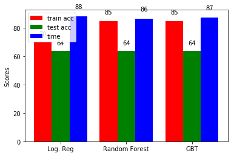

```python
import numpy as np
import matplotlib.pyplot as plt

N = 3
ind = np.arange(N)  # the x locations for the groups
width = 0.27       # the width of the bars

fig = plt.figure()
ax = fig.add_subplot(111)

yvals = [70, 85, 85]
rects1 = ax.bar(ind, yvals, width, color='r')
zvals = [64,64,64]
rects2 = ax.bar(ind+width, zvals, width, color='g')
kvals = [88.38,86.68,87.50]
rects3 = ax.bar(ind+width*2, kvals, width, color='b')

ax.set_ylabel('Scores')
ax.set_xticks(ind+width)
ax.set_xticklabels( ('Log. Reg', 'Random Forest', 'GBT') )
ax.legend( (rects1[0], rects2[0], rects3[0]), ('train acc', 'test acc', 'time') )

def autolabel(rects):
    for rect in rects:
        h = rect.get_height()
        ax.text(rect.get_x()+rect.get_width()/2., 1.05*h, '%d'%int(h),
                ha='center', va='bottom')

autolabel(rects1)
autolabel(rects2)
autolabel(rects3)

plt.show()
```

### Step 3 # redefining churn as only customer which are cancelled the services

```python
final_data = feat_1.join(feat_2, 'userId', 'inner').join(feat_3, 'userId', 'inner').join(feat_4, 'userId', 'inner')\
             .join(feat_5, 'userId', 'inner').join(feat_6, 'userId', 'inner').join(feat_2A, 'userId', 'inner').join(feat_2B, 'userId', 'inner')\
             .join(feat_2C, 'userId', 'inner').join(feat_2D, 'userId', 'inner').join(feat_3A, 'userId', 'inner').join(feat_3B, 'userId', 'inner').join(feat_3C, 'userId', 'inner').join(feat_4A, 'userId', 'inner').drop('userId')

final_data.show()
```

```
+-------------+---------+----------+-----------+------------+-------------+--------------+--------+--------+-----------+------+------------------+------------------+-----------+
|tot_thumbs_up|tot_songs|tot_artist|tot_friends|tot_playlist|user_upgraded|tot_thumb_down|tot_errs|tot_help|tot_setting|gender|   tot_listen_time|      tot_lifetime|user_cancle|
+-------------+---------+----------+-----------+------------+-------------+--------------+--------+--------+-----------+------+------------------+------------------+-----------+
|           17|      275|       275|          4|           7|            0|             5|       0|       2|          0|     0| 66940.89735000003|  55.6436574074074|          0|
|           21|      387|       387|          4|           8|            1|             6|       0|       2|          0|     1| 94008.87593999993| 70.07462962962963|          0|
|            0|        8|         8|          0|           0|            0|             0|       0|       0|          0|     1|2089.1131000000005| 71.31688657407408|          1|
|          171|     4079|      4079|         74|         118|            0|            41|       6|      23|          6|     0|1012312.0927899999|131.55591435185184|          0|
|          100|     2111|      2111|         28|          52|            0|            21|       1|      12|          1|     1| 523275.8428000004|19.455844907407407|          1|
|            7|      150|       150|          1|           5|            0|             1|       1|       1|          1|     1| 38034.08710000002| 72.77818287037037|          0|
|           81|     1914|      1914|         31|          59|            0|            14|       2|       8|          2|     1|477307.60581000015|56.513576388888886|          0|
|          163|     2841|      2841|         33|          72|            1|            29|       1|      17|          3|     0| 711344.9195400011|110.75168981481481|          1|
|           58|      820|       820|         11|          24|            1|             3|       3|       9|          0|     0|       198779.2919|23.556018518518517|          0|
|           17|      257|       257|          6|           7|            0|             3|       0|       2|          0|     1| 67703.47208000004| 85.08340277777778|          1|
|           96|     1928|      1928|         41|          38|            1|            17|       3|      16|          4|     0| 483118.9038399997|  66.8891087962963|          0|
|           11|       84|        84|          3|           1|            0|             0|       0|       1|          0|     0|20660.023910000007|23.872037037037035|          0|
|           86|     1797|      1797|         29|          61|            1|            16|       3|      12|          2|     1| 447464.0146699989|53.965937499999995|          1|
|           40|      647|       647|          6|          20|            1|             9|       1|       3|          2|     0|159669.96303999983|124.47825231481481|          0|
|           95|     2070|      2070|         41|          67|            1|            24|       1|      13|          4|     1| 512449.8827599989| 66.62668981481481|          0|
|          303|     3632|      3632|         63|         113|            0|            28|       5|      27|          3|     0| 897406.9802100015| 74.35851851851852|          0|
|           11|      230|       230|          7|           7|            0|             5|       2|       0|          0|     1| 57633.17563999999| 64.73886574074074|          1|
|          154|     3028|      3028|         47|          89|            1|            22|       0|      28|          4|     1| 754517.5625700009|60.104050925925925|          1|
|           72|     1125|      1125|         12|          33|            1|             9|       4|       7|          1|     0| 286064.0256399999| 71.42444444444445|          0|
|            9|      215|       215|          7|           7|            0|             3|       0|       1|          3|     1| 53062.74659000002| 87.46262731481481|          0|
+-------------+---------+----------+-----------+------------+-------------+--------------+--------+--------+-----------+------+------------------+------------------+-----------+
only showing top 20 rows
```

```python
final_data=final_data.withColumnRenamed("user_cancle","target")
```

```python
churn_Detection(final_data)
```

[output not shown]

```python
rf = RandomForestClassifier(labelCol="label", featuresCol="Scaled_features",numTrees=10)
churn_Detection_v2(final_data,rf)
```

```
 time taken  for training : 70.32248139381409
Total cases :-  25
True positive :-  1
True negative :-  17
False positive :-  0
False negative :-  7
accuracy :-  0.72
Precision :-  1.0
Recall :-  0.125
F1 Score :-  0.2222222222222222
```

```
{'accuracy': 0.72,
 'recall': 0.125,
 'Precision': 1.0,
 'F1': 0.2222222222222222,
 'time': 70.32248139381409}
```

```python
gbtrees = GBTClassifier(labelCol="label", featuresCol="Scaled_features", maxIter=10)
churn_Detection_v2(final_data,rf)
```

```
 time taken  for training : 71.10036706924438
Total cases :-  25
True positive :-  1
True negative :-  17
False positive :-  0
False negative :-  7
accuracy :-  0.72
Precision :-  1.0
Recall :-  0.125
F1 Score :-  0.2222222222222222
```

```
{'accuracy': 0.72,
 'recall': 0.125,
 'Precision': 1.0,
 'F1': 0.2222222222222222,
 'time': 71.10036706924438}
```

### step 4 hyper parameter tuning

```python
# Tuning Hyperparameters for the Gradient Boosting Trees model using Grid Search
gbt_clf = GBTClassifier(maxIter = 15, seed = 42,labelCol="label", featuresCol="Scaled_features")

param_grid_gbt = ParamGridBuilder().addGrid(gbt_clf.maxIter, [10, 15, 20])\
                 .addGrid(gbt_clf.maxDepth, [5, 10]).build()

f1_evaluation = MulticlassClassificationEvaluator(metricName = 'f1')

cross_val_gbt = CrossValidator(estimator = gbt_clf, estimatorParamMaps = param_grid_gbt, evaluator = f1_evaluation, numFolds = 2)
```

```python
#combine all the features in one single feature vector.
cols=final_data.columns
cols.remove('target')
assembler = VectorAssembler(inputCols=cols,outputCol="features")
# Now let us use the transform method to transform our dataset
final_data=assembler.transform(final_data)
#final_data.select("features").show()
#2 Standardsize data
standardscaler=StandardScaler().setInputCol("features").setOutputCol("Scaled_features")
final_data=standardscaler.fit(final_data).transform(final_data)
#final_data.select("features","Scaled_features").show()
#Train test split
data = final_data.select(final_data.target.alias("label"), final_data.Scaled_features.alias("Scaled_features"))
train, test = data.randomSplit([0.85, 0.15], seed=42)
train = train.cache()
```

```python
cv_model_gbt = cross_val_gbt.fit(train)
cv_model_gbt.avgMetrics
```

```
[0.6750231737571564,
 0.6354058492794348,
 0.6601030802186418,
 0.6354058492794348,
 0.6778667302823652,
 0.6354058492794348]
```

```python
cv_model_gbt.bestModel
```

```
GBTClassificationModel (uid=GBTClassifier_8eb3f12856d7) with 20 trees
```

# Final Steps

Clean up your code, adding comments and renaming variables to make the code easier to read and maintain. Refer to the Spark Project Overview page and Data Scientist Capstone Project Rubric to make sure you are including all components of the capstone project and meet all expectations. Remember, this includes thorough documentation in a README file in a Github repository, as well as a web app or blog post.

**Business Objective** with accuracy closer to 60% I think, I have met business object. Although I can improve the accuracy, clearly by doing more inteligent feature selection.

**Learning Objective** I learned a lot in this exercise. I explore pandas vs spark dataframe and also spark sql vs spark declarrivtive I must admit I prefered spark sql and ended up using more spqrk sql APIS.

**blog link** : https://medium.com/@odmirajkar/spark-vs-pandas-f149caa2d643

**Future Steps**

Although Accuracy may seems low but I think one reason is I have defined churn as downgraded as well as cancelled users, These are technically two different types of churn and should be treated differently. so in next iteration i will create two classifiers to identify churn and downgrading users